# ARIMA Models in R

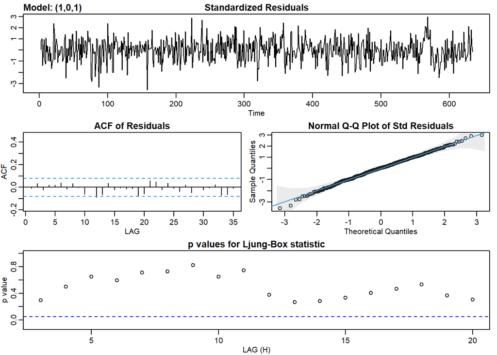

```
## $fit
##
## Call:
## stats::arima(x = xdata, order = c(p, d, q), seasonal = list(order = c(P, D,
##     Q), period = S), xreg = xmean, include.mean = FALSE, transform.pars = trans,
##     fixed = fixed, optim.control = list(trace = trc, REPORT = 1, reltol = tol))
##
## Coefficients:
##          ar1      ma1    xmean
##       0.2341  -0.8871  -0.0013
## s.e.  0.0518   0.0292   0.0028
##
## sigma^2 estimated as 0.2284:  log likelihood = -431.33,  aic = 870.66
##
## $degrees_of_freedom
## [1] 630
##
## $ttable
##       Estimate     SE  t.value p.value
## ar1     0.2341 0.0518   4.5184  0.0000
## ma1    -0.8871 0.0292 -30.4107  0.0000
## xmean  -0.0013 0.0028  -0.4618  0.6444
##
## $AIC
## [1] 1.375456
##
## $AICc
## [1] 1.375517
##
## $BIC
## [1] 1.403579
```

```r
# Fit an ARMA(1,1) to dl_varve. Improvement?
sarima(dl_varve, p = 1, d = 0, q = 1)
```

IC and BIC help you find the model with the smallest error using the least number of parameters. The idea is based on the *parsimony principle*, which is basic to all science and tells you to choose the simplest scientific explanation that fits the evidence.

**Residual analysis - I**

As you saw in the video, an `sarima()` run includes a residual analysis graphic. Specifically, the output shows (1) the standardized residuals, (2) the sample ACF of the residuals, (3) a normal Q-Q plot, and (4) the p-values corresponding to the Box-Ljung-Pierce Q-statistic.

In each run, check the four residual plots as follows (model assumes errors are Gaussian white noise):

1. The standardized residuals should behave as a white noise sequence with mean zero and variance one. Examine the residual plot for departures from this behavior.
2. The sample ACF of the residuals should look like that of white noise. Examine the ACF for departures from this behavior.
3. Normality is an essential assumption when fitting ARMA models. Examine the Q-Q plot for departures from normality and to identify outliers.
4. Use the Q-statistic plot to help test for departures from whiteness of the residuals.

As in the previous exercise, `dl_varve <- diff(log(varve))`, which is plotted below a plot of `varve`. The [astsa](https://www.rdocumentation.org/packages/astsa/versions/1.6/) package is preloaded.

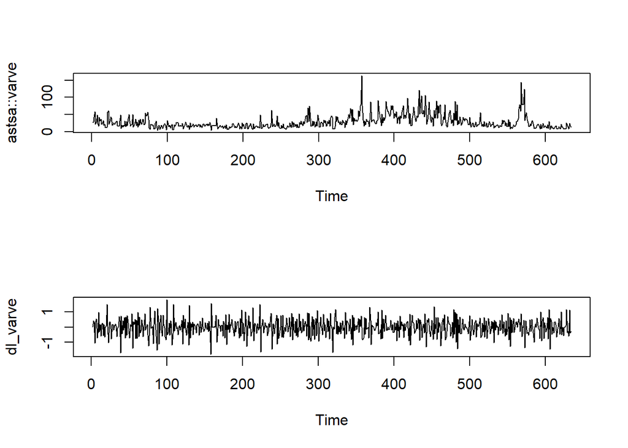

```r
par(mfrow = c(2,1))
plot(astsa::varve)
plot(dl_varve)
```

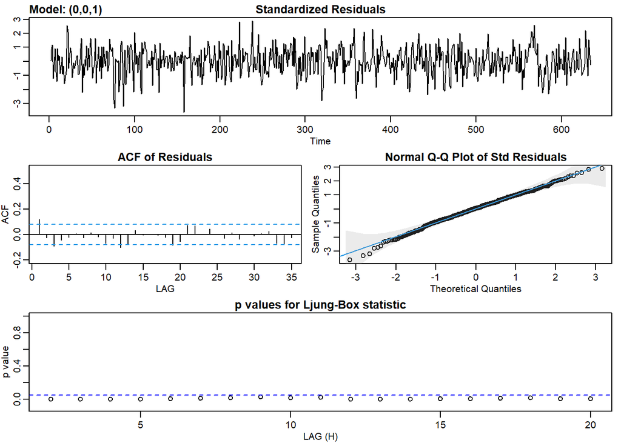

```
## $fit
##
## Call:
## stats::arima(x = xdata, order = c(p, d, q), seasonal = list(order = c(P, D,
##     Q), period = S), xreg = xmean, include.mean = FALSE, transform.pars = trans,
##     fixed = fixed, optim.control = list(trace = trc, REPORT = 1, reltol = tol))
##
## Coefficients:
##           ma1    xmean
##       -0.7710  -0.0013
## s.e.   0.0341   0.0044
##
## sigma^2 estimated as 0.2353:  log likelihood = -440.68,  aic = 887.36
##
## $degrees_of_freedom
## [1] 631
##
## $ttable
##       Estimate     SE  t.value p.value
## ma1    -0.7710 0.0341 -22.6002  0.0000
## xmean  -0.0013 0.0044  -0.2818  0.7782
##
## $AIC
## [1] 1.401826
##
## $AICc
## [1] 1.401856
##
## $BIC
## [1] 1.422918
```

```r
# Fit an MA(1) to dl_varve. Examine the residuals
sarima(dl_varve, p = 0, d = 0, q = 1)
```

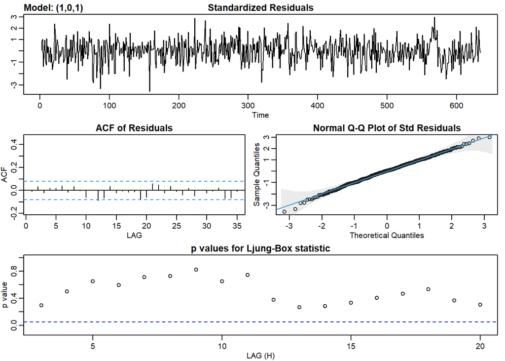

```
## $fit
##
## Call:
## stats::arima(x = xdata, order = c(p, d, q), seasonal = list(order = c(P, D,
##     Q), period = S), xreg = xmean, include.mean = FALSE, transform.pars = trans,
##     fixed = fixed, optim.control = list(trace = trc, REPORT = 1, reltol = tol))
##
## Coefficients:
##          ar1      ma1    xmean
##       0.2341  -0.8871  -0.0013
## s.e.  0.0518   0.0292   0.0028
##
## sigma^2 estimated as 0.2284:  log likelihood = -431.33,  aic = 870.66
##
## $degrees_of_freedom
## [1] 630
##
## $ttable
##       Estimate     SE  t.value p.value
## ar1     0.2341 0.0518   4.5184  0.0000
## ma1    -0.8871 0.0292 -30.4107  0.0000
## xmean  -0.0013 0.0028  -0.4618  0.6444
##
## $AIC
## [1] 1.375456
##
## $AICc
## [1] 1.375517
##
## $BIC
## [1] 1.403579
```

```r
# Fit an ARMA(1,1) to dl_varve. Examine the residuals
sarima(dl_varve, p = 1, d = 0, q = 1)
```

By now you have mastered constructing parameters through the `sarima()` command, but the rich and comprehensive output of this command is always worth exploring. What did you learn about the residuals produced by your MA(1) and ARMA(1,1) models?

**ARMA get in** By now you have gained considerable experience fitting ARMA models to data, but before you start celebrating, try one more exercise (sort of) on your own.

The data in `oil` are crude oil, WTI spot price FOB (in dollars per barrel), weekly data from 2000 to 2008. Use your skills to fit an ARMA model to the returns. The weekly crude oil prices (`oil`) are plotted for you. Throughout the exercise, work with the returns, which you will calculate.

As before, the **astsa** package is preloaded for you. The data are preloaded as `oil`.

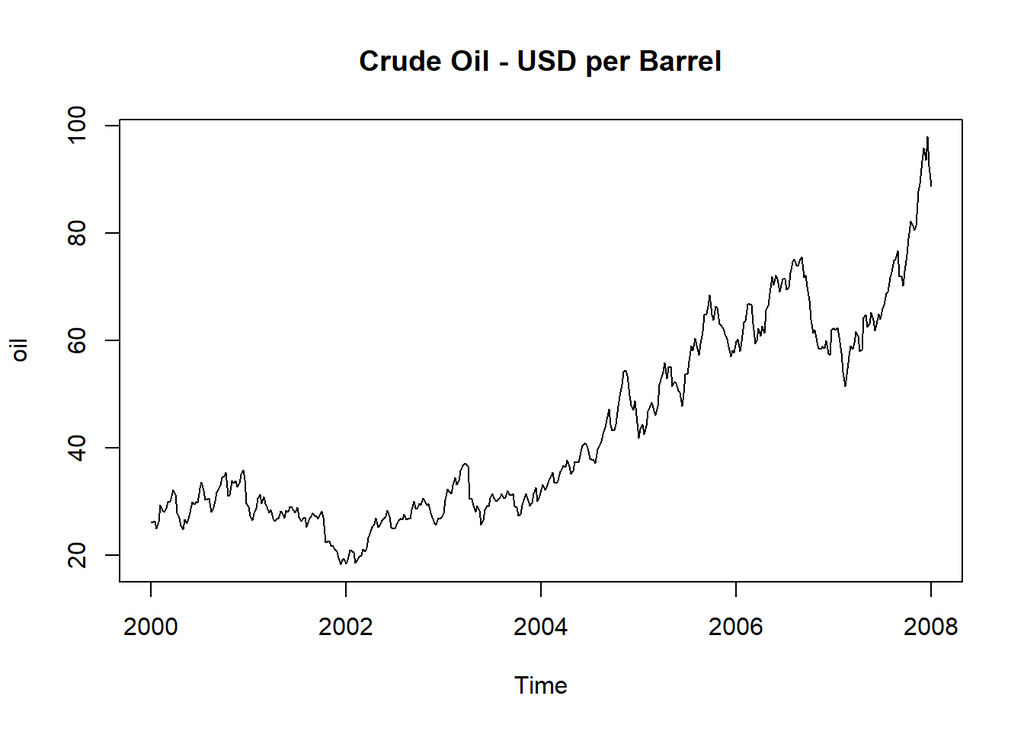

```r
oil <- ts(astsa::oil, start = 2000, end = 2008, frequency = 52)
plot(oil, main = "Crude Oil - USD per Barrel")
```

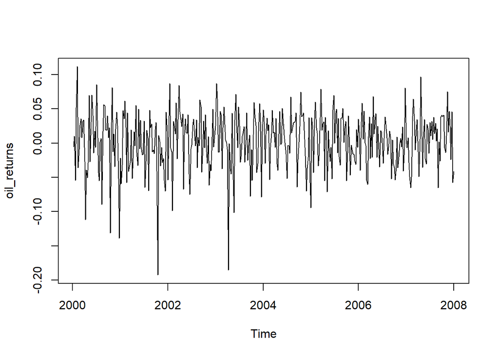

```r
# Calculate approximate oil returns
oil_returns <- diff(log(oil))

# Plot oil_returns. Notice the outliers.
plot(oil_returns)
```

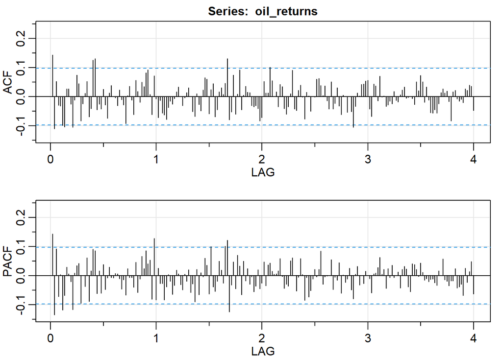

[output not shown]

```r
# Plot the P/ACF pair for oil_returns
acf2(oil_returns)
```

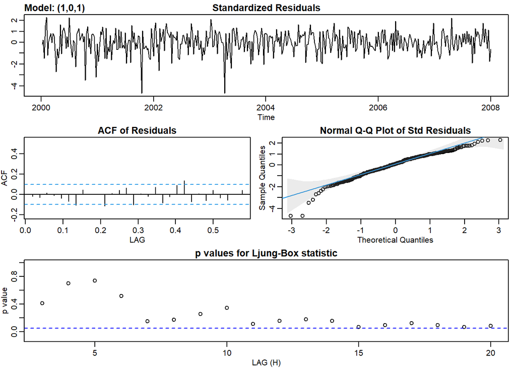

```
## $fit
##
## Call:
## stats::arima(x = xdata, order = c(p, d, q), seasonal = list(order = c(P, D,
##     Q), period = S), xreg = xmean, include.mean = FALSE, transform.pars = trans,
##     fixed = fixed, optim.control = list(trace = trc, REPORT = 1, reltol = tol))
##
## Coefficients:
##           ar1     ma1   xmean
##       -0.4752  0.6768  0.0029
## s.e.   0.1084  0.0871  0.0022
##
## sigma^2 estimated as 0.001589:  log likelihood = 750.22,  aic = -1492.43
##
## $degrees_of_freedom
## [1] 413
##
## $ttable
##       Estimate     SE t.value p.value
## ar1    -0.4752 0.1084 -4.3846  0.0000
## ma1     0.6768 0.0871  7.7674  0.0000
## xmean   0.0029 0.0022  1.3184  0.1881
##
## $AIC
## [1] -3.587576
##
## $AICc
## [1] -3.587436
##
## $BIC
## [1] -3.548819
```

```r
# Assuming both P/ACF are tailing, fit a model
sarima(oil_returns, p = 1, d = 0, q = 1)
```

You have now successfully manipulated some real-world time series data, explored the qualities of that data, and modeled an ARMA(1,1) model to your data. In the next chapter, you will explore more complicated models.

**ARIMA - integrated ARMA**

**Identifying ARIMA**

- a time series exhibits ARIMA behavior if the differenced data has ARMA behavior

**ACF and PCF of an integrated ARMA**

**ARIMA - plug and play**

As you saw in the video, a time series is called $ARIMA(p,d,q)$ if the differenced series (of order $d$) is $ARMA(p,q)$.

To get a sense of how the model works, you will analyze simulated data from the integrated model

$Y_t =.9Y_{t−1} + W_t$

where $Y_t = \nabla X_t = X_t − X_{t−1}$. In this case, the model is an $ARIMA(1,1,0)$ because the differenced data are an autoregression of order one.

The simulated time series is in `x` and it was generated in R as

```
x <- arima.sim(model = list(order = c(1, 1, 0), ar = .9), n = 200)
```

You will plot the generated data and the sample ACF and PACF of the generated data to see how integrated data behave. Then, you will difference the data to make it stationary. You will plot the differenced data and the corresponding sample ACF and PACF to see how differencing makes a difference.

As before, the [astsa](https://www.rdocumentation.org/packages/astsa/versions/1.6/) package is preloaded in your workspace. Data from an $ARIMA(1,1,0)$ with AR parameter .9 is saved in object `x`.

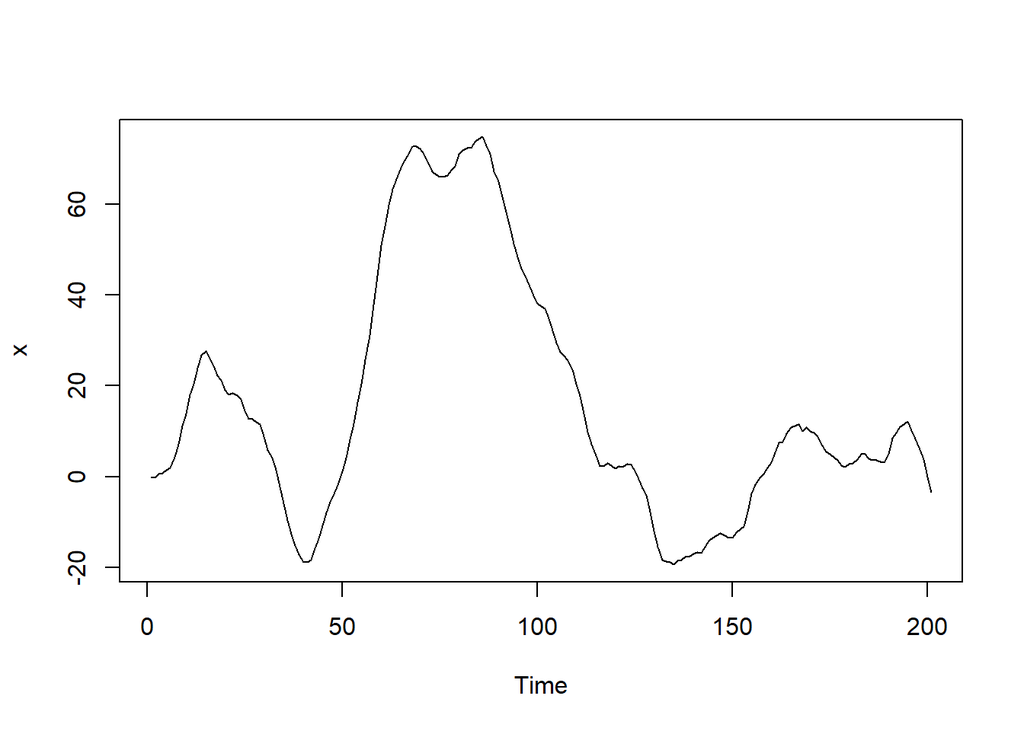

```r
x <- arima.sim(model = list(order = c(1, 1, 0), ar = .9), n = 200)

# Plot x
plot(x)
```

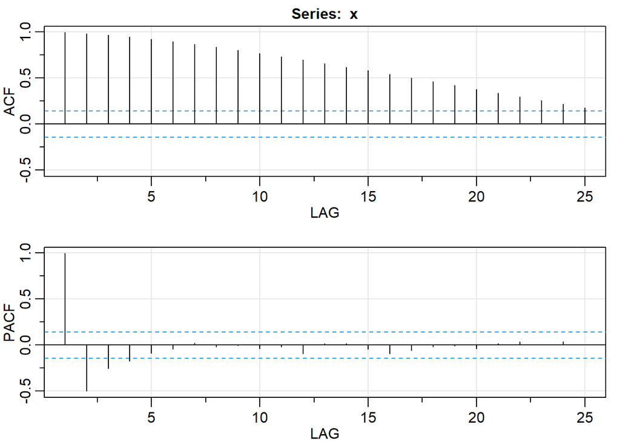

```
##      [,1]  [,2]  [,3]  [,4]  [,5]  [,6] [,7]  [,8] [,9] [,10] [,11] [,12] [,13]
## ACF  0.99  0.98  0.97  0.95  0.92  0.90 0.87  0.83  0.8  0.77  0.73  0.69  0.66
## PACF 0.99 -0.50 -0.26 -0.17 -0.09 -0.04 0.02 -0.02  0.0 -0.04 -0.02 -0.10  0.01
##      [,14] [,15] [,16] [,17] [,18] [,19] [,20] [,21] [,22] [,23] [,24] [,25]
## ACF   0.62  0.58  0.54  0.50  0.46  0.42  0.38  0.34  0.29  0.25  0.21  0.18
## PACF  0.02 -0.05 -0.09 -0.06 -0.02 -0.01 -0.04  0.02  0.04  0.00  0.04  0.01
```

```r
# Plot the P/ACF pair of x
acf2(x)
```

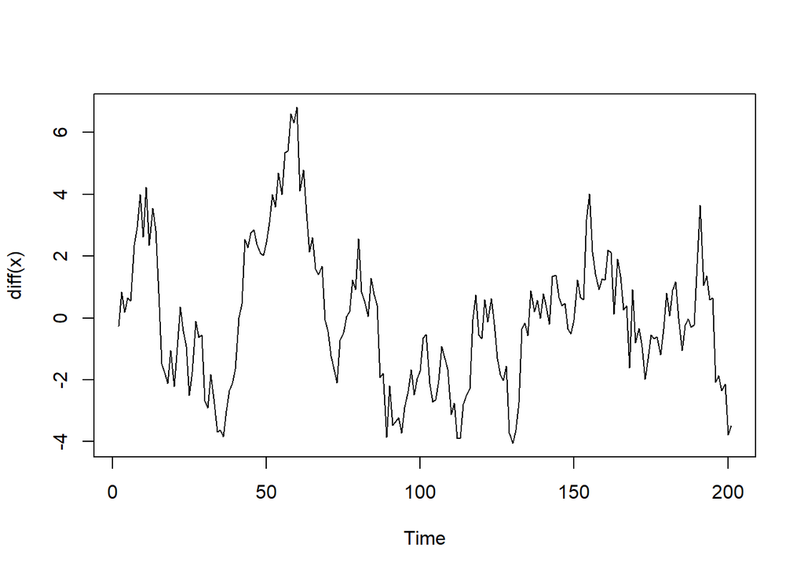

```r
# Plot the differenced data
plot(diff(x))
```

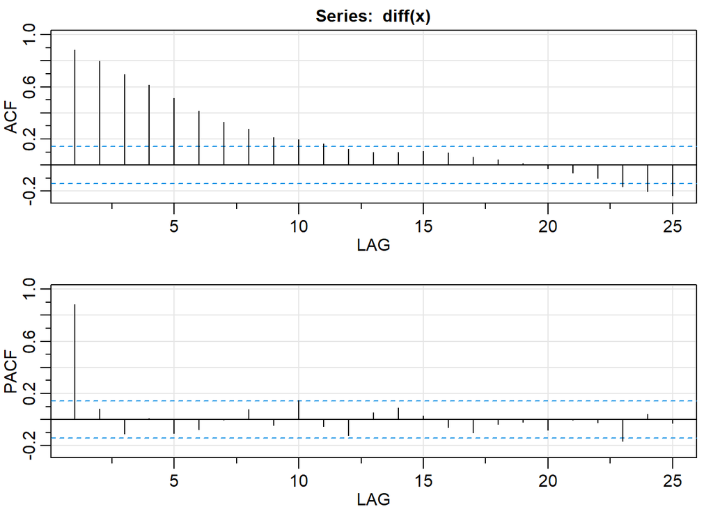

```
##      [,1] [,2]  [,3] [,4]  [,5]  [,6] [,7] [,8]  [,9] [,10] [,11] [,12] [,13]
## ACF  0.88 0.80  0.70 0.61  0.51  0.42 0.33 0.28  0.21  0.20  0.16  0.12  0.10
## PACF 0.88 0.08 -0.11 0.01 -0.10 -0.08 0.00 0.08 -0.04  0.15 -0.05 -0.12  0.05
##      [,14] [,15] [,16] [,17] [,18] [,19] [,20] [,21] [,22] [,23] [,24] [,25]
## ACF   0.10  0.11  0.09  0.06  0.04  0.01 -0.03 -0.06 -0.10 -0.16 -0.20 -0.23
## PACF  0.09  0.03 -0.06 -0.10 -0.04 -0.02 -0.08  0.00 -0.02 -0.17  0.04 -0.03
```

```r
# Plot the P/ACF pair of the differenced data
acf2(diff(x))
```

As you can see, differencing the data in your $ARIMA(1,1,0)$ model makes it stationary and allows for further analysis.

**Simulated ARIMA**

Before analyzing actual time series data, you should try working with a slightly more complicated model.

Here, we generated 250 observations from the $ARIMA(2,1,0)$ model with drift given by

$Y_t = 1 + 1.5Y_{t−1} − .75Y_{t−2} + W_t$

where $Y_t = \nabla X_t = X_t − X_{t−1}$.

You will use the established techniques to fit a model to the data.

The **astsa** package is preloaded and the generated data are in `x`. The series `x` and the detrended series`y <- diff(x)` have been plotted.

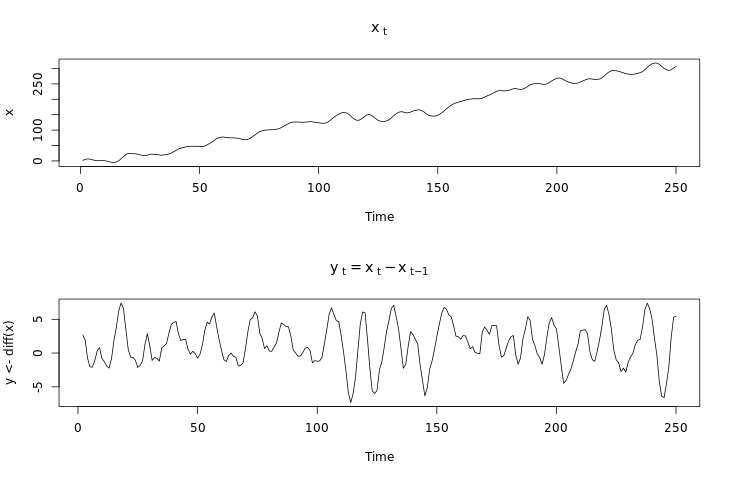

```
# Plot sample P/ACF of differenced data and determine model
acf2(diff(x))
```

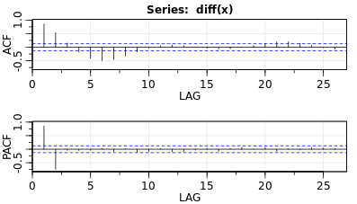

```
# Estimate parameters and examine output
sarima(x, p = 2, d = 1, q = 0)
```

```
Call:
stats::arima(x = xdata, order = c(p, d, q), seasonal = list(order = c(P, D,
    Q), period = S), xreg = constant, transform.pars = trans, fixed = fixed,
    optim.control = list(trace = trc, REPORT = 1, reltol = tol))

Coefficients:
         ar1      ar2  constant
      1.5197  -0.7669    1.2335
s.e.  0.0401   0.0401    0.2570

sigma^2 estimated as 1.004:  log likelihood = -355.41,  aic = 718.82

$degrees_of_freedom
[1] 246

$ttable
         Estimate     SE  t.value p.value
ar1        1.5197 0.0401  37.9191       0
ar2       -0.7669 0.0401 -19.1321       0
constant   1.2335 0.2570   4.7996       0

$AIC
[1] 2.886818

$AICc
[1] 2.887211

$BIC
[1] 2.943323
```

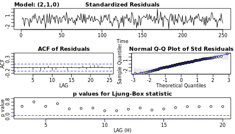

As you can see from your t-table, the estimated parameters are very close to 1.5 and -0.75.

**Global warming**

Now that you have some experience fitting an ARIMA model to simulated data, your next task is to apply your skills to some real world data.

The data in `globtemp` (from astsa) are the annual global temperature deviations to 2015. In this exercise, you will use established techniques to fit an ARIMA model to the data. A plot of the data shows random walk behavior, which suggests you should work with the *differenced* data. The differenced data `diff(globtemp)` are also plotted.

After plotting the sample ACF and PACF of the differenced data `diff(globtemp)`, you can say that either

1. The ACF and the PACF are both tailing off, implying an ARIMA(1,1,1) model.
2. The ACF cuts off at lag 2, and the PACF is tailing off, implying an ARIMA(0,1,2) model.
3. The ACF is tailing off and the PACF cuts off at lag 3, implying an ARIMA(3,1,0) model. Although this model fits reasonably well, it is the worst of the three (you can check it) because it uses too many parameters for such small autocorrelations.

After fitting the first two models, check the AIC and BIC to choose the preferred model.

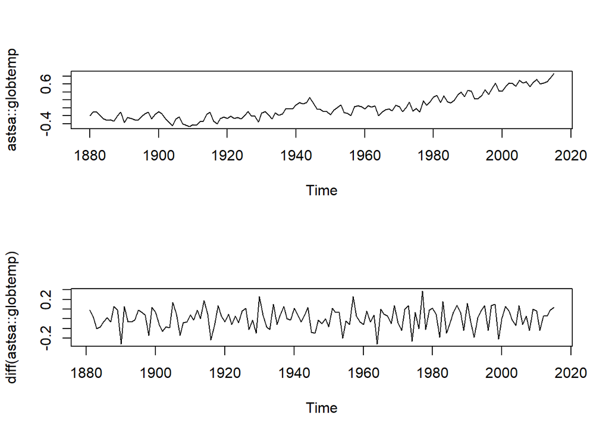

```r
par(mfrow = c(2,1))
plot(astsa::globtemp)
plot(diff(astsa::globtemp))
```

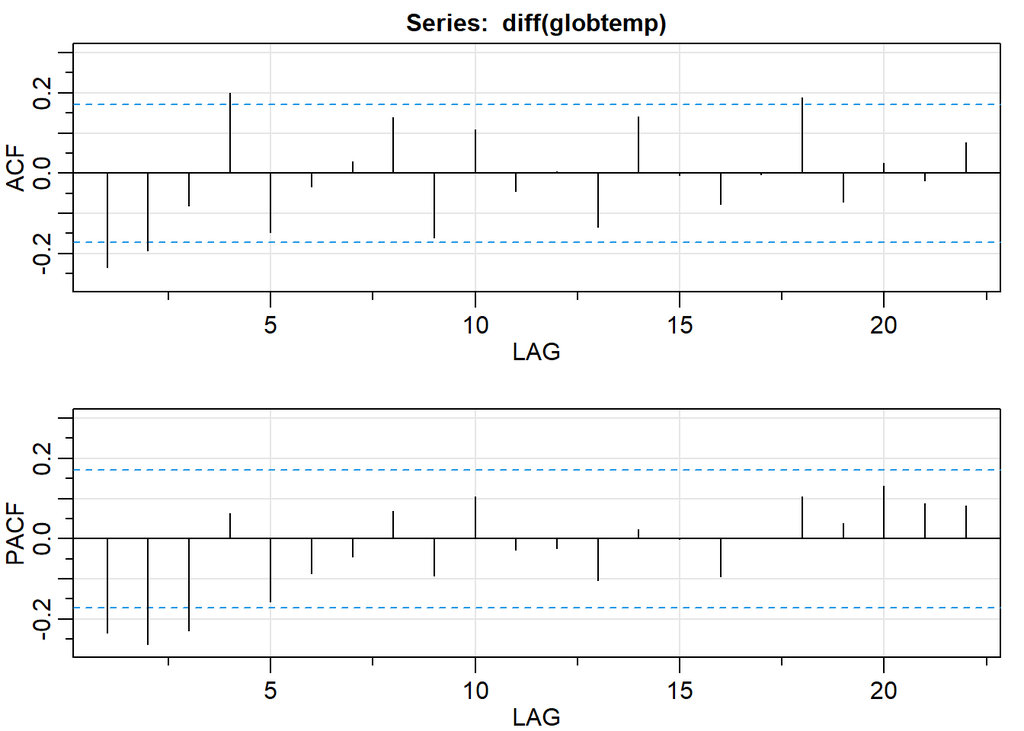

```
##       [,1]  [,2]  [,3] [,4]  [,5]  [,6]  [,7] [,8]  [,9] [,10] [,11] [,12]
## ACF  -0.24 -0.19 -0.08 0.20 -0.15 -0.03  0.03 0.14 -0.16  0.11 -0.05  0.00
## PACF -0.24 -0.26 -0.23 0.06 -0.16 -0.09 -0.05 0.07 -0.09  0.11 -0.03 -0.02
##      [,13] [,14] [,15] [,16] [,17] [,18] [,19] [,20] [,21] [,22]
## ACF  -0.13  0.14 -0.01 -0.08     0  0.19 -0.07  0.02 -0.02  0.08
## PACF -0.10  0.02  0.00 -0.09     0  0.11  0.04  0.13  0.09  0.08
```

```r
# Plot the sample P/ACF pair of the differenced data
acf2(diff(globtemp))
```

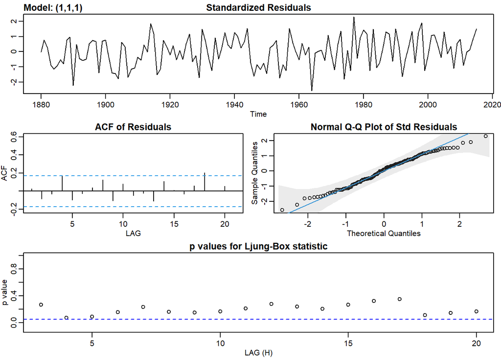

```
## $fit
##
## Call:
## stats::arima(x = xdata, order = c(p, d, q), seasonal = list(order = c(P, D,
##     Q), period = S), xreg = constant, transform.pars = trans, fixed = fixed,
##     optim.control = list(trace = trc, REPORT = 1, reltol = tol))
##
## Coefficients:
##          ar1      ma1  constant
##       0.3549  -0.7663    0.0072
## s.e.  0.1314   0.0874    0.0032
##
## sigma^2 estimated as 0.009885:  log likelihood = 119.88,  aic = -231.76
##
## $degrees_of_freedom
## [1] 132
##
## $ttable
##          Estimate     SE t.value p.value
## ar1        0.3549 0.1314  2.7008  0.0078
## ma1       -0.7663 0.0874 -8.7701  0.0000
## constant   0.0072 0.0032  2.2738  0.0246
##
## $AIC
## [1] -1.716773
##
## $AICc
## [1] -1.715416
##
## $BIC
## [1] -1.630691
```

```r
# Fit an ARIMA(1,1,1) model to globtemp
sarima(globtemp, p = 1, d = 1, q = 1)
```

```r
# Fit an ARIMA(0,1,2) model to globtemp. Which model is better?
sarima(globtemp, p = 0, d = 1, q = 2)
```

```
## $fit
##
## Call:
## stats::arima(x = xdata, order = c(p, d, q), seasonal = list(order = c(P, D,
##     Q), period = S), xreg = constant, transform.pars = trans, fixed = fixed,
##     optim.control = list(trace = trc, REPORT = 1, reltol = tol))
##
## Coefficients:
##           ma1      ma2  constant
##       -0.3984  -0.2173    0.0072
## s.e.   0.0808   0.0768    0.0033
##
## sigma^2 estimated as 0.00982:  log likelihood = 120.32,  aic = -232.64
##
## $degrees_of_freedom
## [1] 132
##
## $ttable
##          Estimate     SE t.value p.value
## ma1       -0.3984 0.0808 -4.9313  0.0000
## ma2       -0.2173 0.0768 -2.8303  0.0054
## constant   0.0072 0.0033  2.1463  0.0337
##
## $AIC
## [1] -1.723268
##
## $AICc
## [1] -1.721911
##
## $BIC
## [1] -1.637185
```

Judging by the AIC and BIC, the ARIMA(0,1,2) model performs better than the ARIMA(1,1,1) model on the `globtemp` data. Remember to thoroughly examine the output of your `sarima()` command to gain a full understanding of your model.

**ARIMA diagnostics**

**Diagnostics - simulated overfitting**

One way to check an analysis is to overfit the model by adding an extra parameter to see if it makes a difference in the results. If adding parameters changes the results drastically, then you should rethink your model. If, however, the results do not change by much, you can be confident that your fit is correct.

We generated 250 observations from an ARIMA(0,1,1) model with MA parameter .9. First, you will fit the model to the data using established techniques.

As usual, the astsa package is preloaded and the generated data in `x` are plotted in your workspace. The differenced data `diff(x)` are also plotted. Note that it looks stationary.

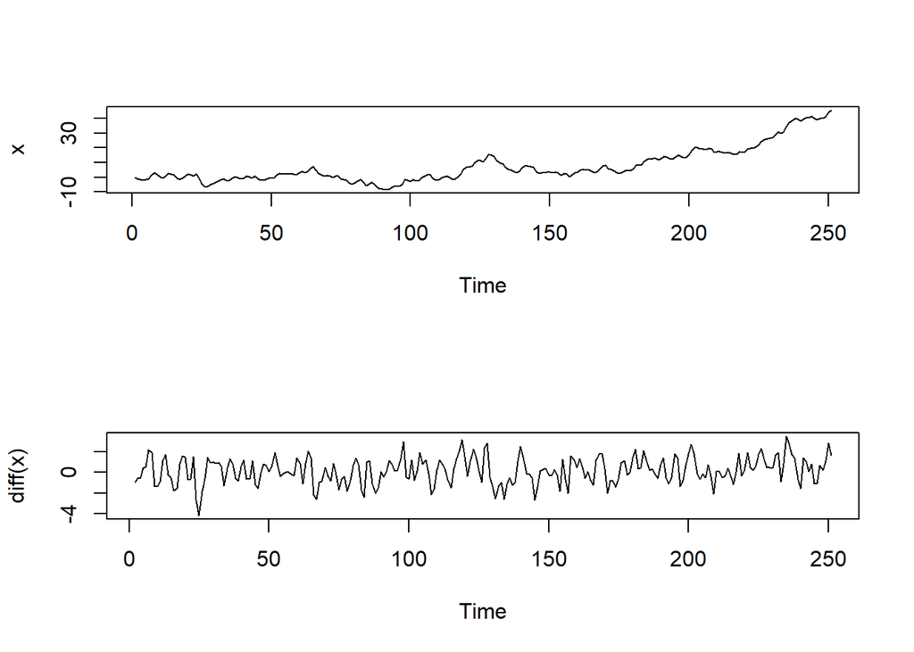

```r
x <- arima.sim(model = list(order = c(0, 1, 1), ma = .9), n = 250)

par(mfrow = c(2,1))
plot(x)
plot(diff(x))
```

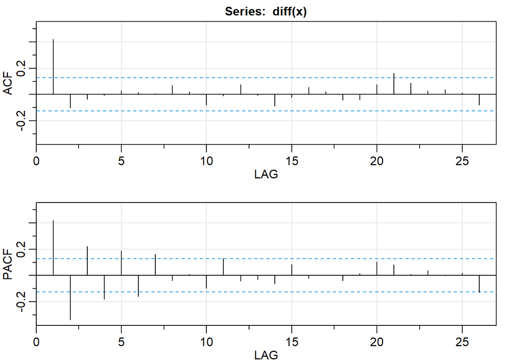

```
##      [,1]  [,2]  [,3]  [,4] [,5]  [,6] [,7]  [,8] [,9] [,10] [,11] [,12] [,13]
## ACF  0.42 -0.10 -0.04 -0.01 0.03  0.02 0.01  0.07 0.02 -0.08 -0.01  0.08 -0.01
## PACF 0.42 -0.34  0.22 -0.18 0.19 -0.16 0.16 -0.04 0.01 -0.10  0.13 -0.04 -0.03
##      [,14] [,15] [,16] [,17] [,18] [,19] [,20] [,21] [,22] [,23] [,24] [,25]
## ACF  -0.09 -0.02  0.06  0.02 -0.04 -0.04  0.08  0.16  0.09  0.03  0.04  0.01
## PACF -0.06  0.08 -0.02  0.00 -0.04  0.02  0.10  0.08  0.01  0.04  0.00  0.02
##      [,26]
## ACF  -0.08
## PACF -0.13
```

```r
# Plot sample P/ACF pair of the differenced data
acf2(diff(x))
```

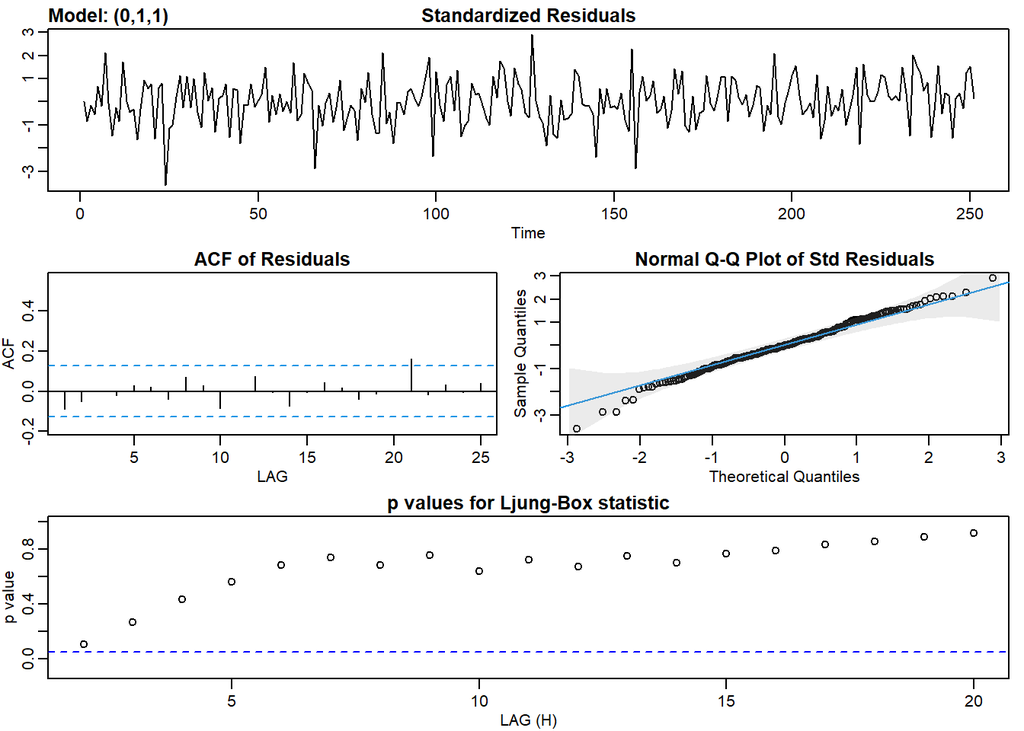

```
## $fit
##
## Call:
## stats::arima(x = xdata, order = c(p, d, q), seasonal = list(order = c(P, D,
##     Q), period = S), xreg = constant, transform.pars = trans, fixed = fixed,
##     optim.control = list(trace = trc, REPORT = 1, reltol = tol))
##
## Coefficients:
##          ma1  constant
##       0.9071    0.1810
## s.e.  0.0359    0.1195
##
## sigma^2 estimated as 0.9855:  log likelihood = -353.77,  aic = 713.55
##
## $degrees_of_freedom
## [1] 248
##
## $ttable
##          Estimate     SE t.value p.value
## ma1        0.9071 0.0359 25.2465  0.0000
## constant   0.1810 0.1195  1.5146  0.1312
##
## $AIC
## [1] 2.854184
##
## $AICc
## [1] 2.854378
##
## $BIC
## [1] 2.896441
```

```r
# Fit the first model, compare parameters, check diagnostics
astsa::sarima(x, p = 0, d = 1, q = 1)
```

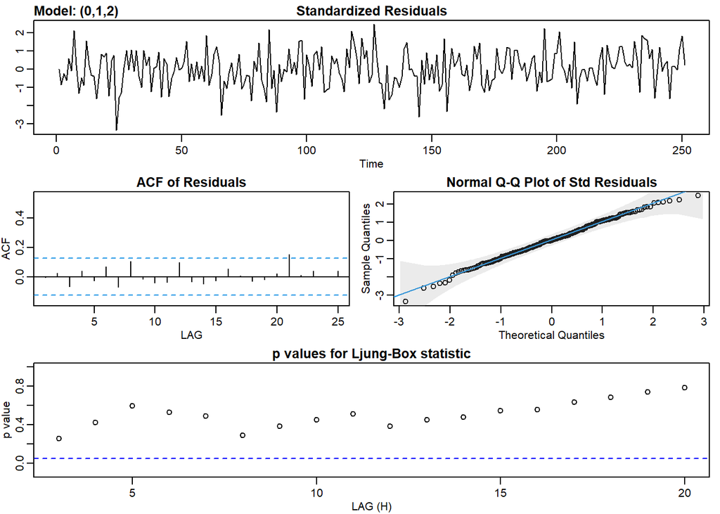

```
## $fit
##
## Call:
## stats::arima(x = xdata, order = c(p, d, q), seasonal = list(order = c(P, D,
##     Q), period = S), xreg = constant, transform.pars = trans, fixed = fixed,
##     optim.control = list(trace = trc, REPORT = 1, reltol = tol))
##
## Coefficients:
##          ma1      ma2  constant
##       0.8328  -0.1672     0.181
## s.e.  0.0636   0.0619     0.103
##
## sigma^2 estimated as 0.9591:  log likelihood = -352.14,  aic = 712.27
##
## $degrees_of_freedom
## [1] 247
##
## $ttable
##          Estimate     SE t.value p.value
## ma1        0.8328 0.0636 13.1030  0.0000
## ma2       -0.1672 0.0619 -2.7018  0.0074
## constant   0.1810 0.1030  1.7571  0.0801
##
## $AIC
## [1] 2.849094
##
## $AICc
## [1] 2.849484
##
## $BIC
## [1] 2.905437
```

```r
# Fit the second model and compare fit
astsa::sarima(x, p = 0, d = 1, q = 2)
```

**Diagnostics - global temperatures**

You can now finish your analysis of global temperatures. Recall that you previously fit two models to the data in `globtemp`, an ARIMA(1,1,1) and an ARIMA(0,1,2). In the final analysis, check the residual diagnostics and use AIC and BIC for model choice.

The data are plotted for you.

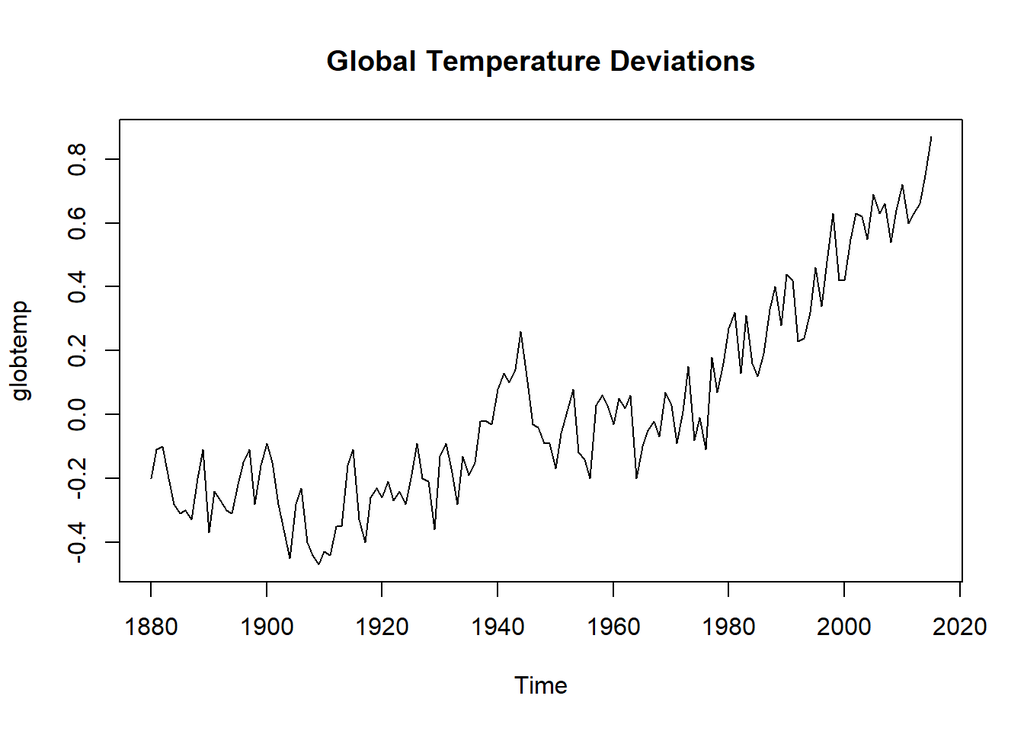

```r
plot(astsa::globtemp, ylab = "globtemp", main = "Global Temperature Deviations")
```

```r
# Fit ARIMA(0,1,2) to globtemp and check diagnostics
sarima(globtemp, p = 0, d = 1, q = 2)
```

```
## $fit
##
## Call:
## stats::arima(x = xdata, order = c(p, d, q), seasonal = list(order = c(P, D,
##     Q), period = S), xreg = constant, transform.pars = trans, fixed = fixed,
##     optim.control = list(trace = trc, REPORT = 1, reltol = tol))
##
## Coefficients:
##           ma1      ma2  constant
##       -0.3984  -0.2173    0.0072
## s.e.   0.0808   0.0768    0.0033
##
## sigma^2 estimated as 0.00982:  log likelihood = 120.32,  aic = -232.64
##
## $degrees_of_freedom
## [1] 132
##
## $ttable
##          Estimate     SE t.value p.value
## ma1       -0.3984 0.0808 -4.9313  0.0000
## ma2       -0.2173 0.0768 -2.8303  0.0054
## constant   0.0072 0.0033  2.1463  0.0337
##
## $AIC
## [1] -1.723268
##
## $AICc
## [1] -1.721911
##
## $BIC
## [1] -1.637185
```

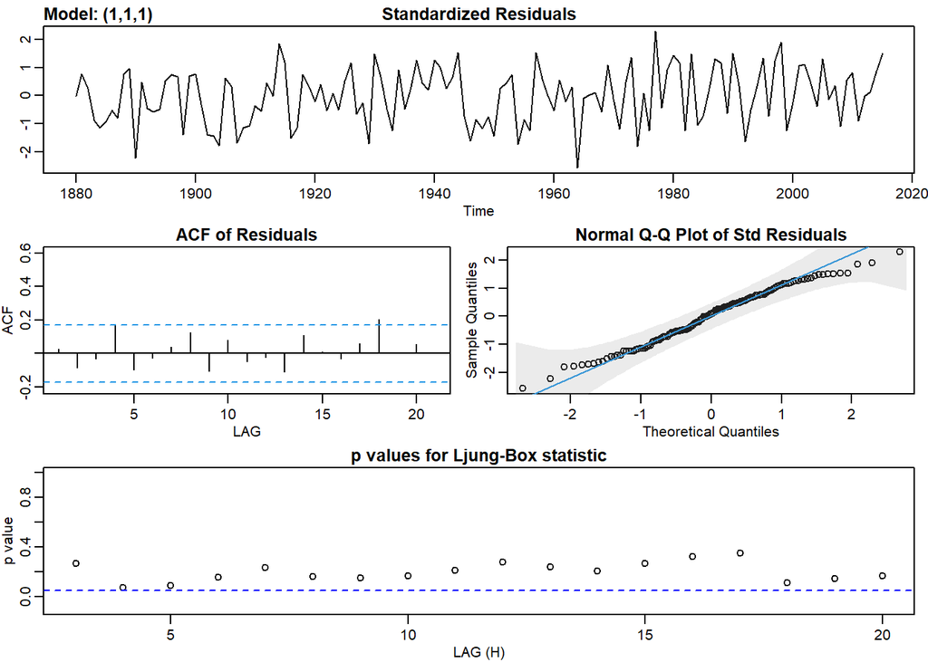

```
## $fit
##
## Call:
## stats::arima(x = xdata, order = c(p, d, q), seasonal = list(order = c(P, D,
##     Q), period = S), xreg = constant, transform.pars = trans, fixed = fixed,
##     optim.control = list(trace = trc, REPORT = 1, reltol = tol))
##
## Coefficients:
##          ar1      ma1  constant
##       0.3549  -0.7663    0.0072
## s.e.  0.1314   0.0874    0.0032
##
## sigma^2 estimated as 0.009885:  log likelihood = 119.88,  aic = -231.76
##
## $degrees_of_freedom
## [1] 132
##
## $ttable
##          Estimate     SE t.value p.value
## ar1        0.3549 0.1314  2.7008  0.0078
## ma1       -0.7663 0.0874 -8.7701  0.0000
## constant   0.0072 0.0032  2.2738  0.0246
##
## $AIC
## [1] -1.716773
##
## $AICc
## [1] -1.715416
##
## $BIC
## [1] -1.630691
```

```r
# Fit ARIMA(1,1,1) to globtemp and check diagnostics
sarima(globtemp, p = 1, d = 1, q = 1)
```

```r
# Which is the better model?
"ARIMA(0,1,2)"
```

```
## [1] "ARIMA(0,1,2)"
```

Your model diagnostics suggest that both the ARIMA(0,1,2) and the ARIMA(1,1,1) are reasonable models. However, the AIC and BIC suggest that the ARIMA(0,1,2) performs slightly better, so this should be your preferred model. Although you were not asked to do so, you can use overfitting to assess the final model. For example, try fitting an ARIMA(1,1,2) or an ARIMA(0,1,3) to the data.

**Forecasting ARIMA**

- the model describes how the dynamics of the time series behave over time.
- forecasting simply continues the mdoel dynamics into the future.
- use `sarima.for()` to forecast in the `astsa-package`
  - red plotted area is predicted values
  - dark gray band is 1 * RMSPE
  - light gray band is 2 * RMSPE

**Forecasting simulated ARIMA**

Now that you are an expert at fitting ARIMA models, you can use your skills for forecasting. First, you will work with simulated data.

We generated 120 observations from an ARIMA(1,1,0) model with AR parameter .9. The data are in `y` and the first 100 observations are in x. These observations are plotted for you. You will fit an ARIMA(1,1,0) model to the data in `x` and verify that the model fits well. Then use [sarima.for()](https://www.rdocumentation.org/packages/astsa/versions/1.6/topics/sarima.for) from `astsa` to forecast the data 20 time periods ahead. You will then compare the forecasts to the actual data in `y`.

The basic syntax for forecasting is `sarima.for(data, n.ahead, p, d, q)` where `n.ahead` is a positive integer that specifies the forecast horizon. The predicted values and their standard errors are printed, the data are plotted in black, and the forecasts are in red along with 2 mean square prediction error bounds as blue dashed lines.

The [astsa](https://www.rdocumentation.org/packages/astsa/versions/1.6/) package is preloaded and the data (`x`) and differenced data (`diff(x)`) are plotted.

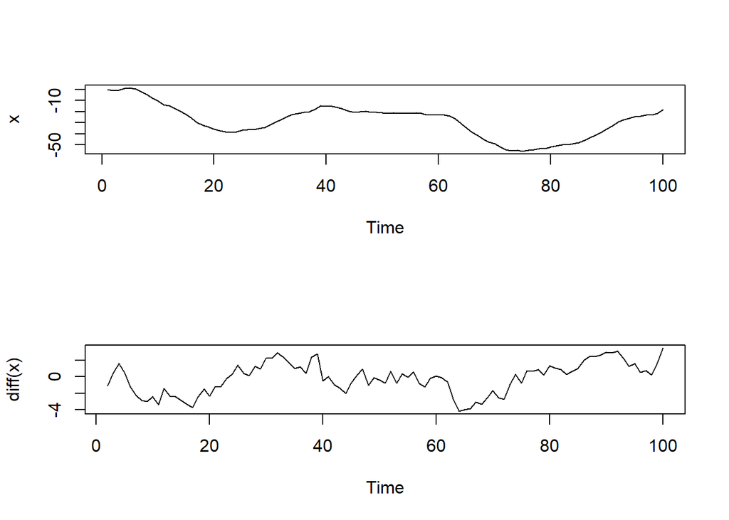

```r
y <- arima.sim(model = list(order = c(1, 1, 0), ar = .9), n = 120)
x <- ts(y, start = 1, end = 100, frequency = 1)

par(mfrow = c(2,1))
plot(x)
plot(diff(x))
```

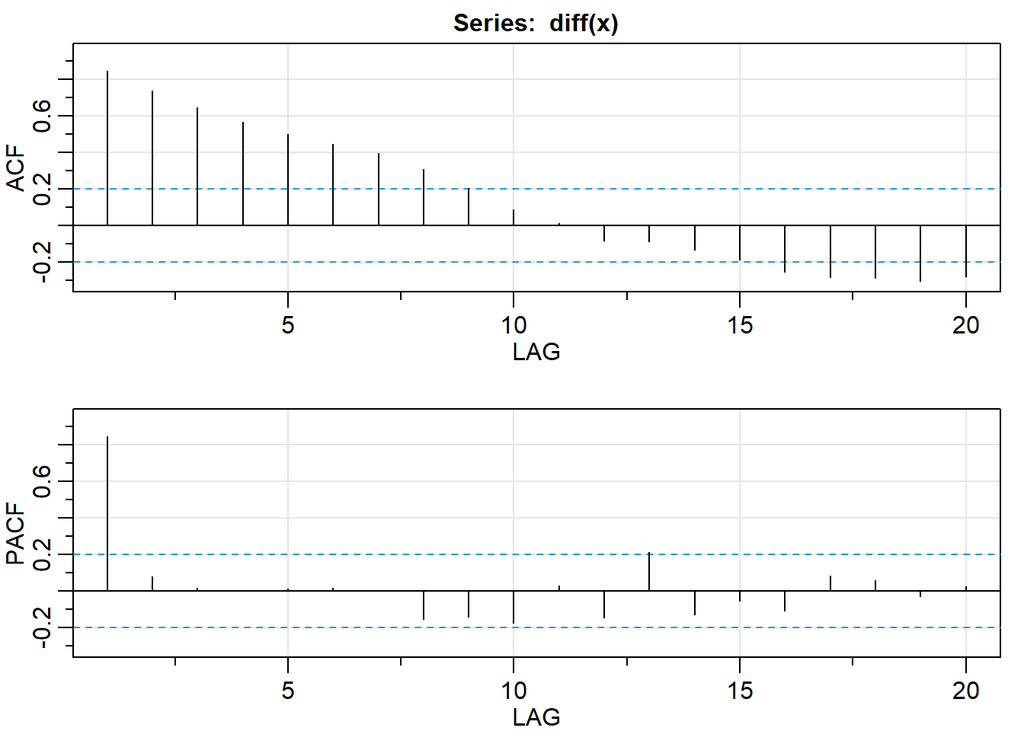

```
##      [,1] [,2] [,3] [,4] [,5] [,6] [,7]  [,8]  [,9] [,10] [,11] [,12] [,13]
## ACF  0.85 0.74 0.65 0.57 0.50 0.44 0.39  0.31  0.21  0.09  0.01 -0.08 -0.09
## PACF 0.85 0.08 0.02 0.00 0.01 0.02 0.00 -0.15 -0.14 -0.17  0.03 -0.15  0.21
##      [,14] [,15] [,16] [,17] [,18] [,19] [,20]
## ACF  -0.13 -0.19 -0.25 -0.28 -0.29 -0.30 -0.28
## PACF -0.13 -0.05 -0.11  0.09  0.06 -0.03  0.03
```

```r
# Plot P/ACF pair of differenced data
astsa::acf2(diff(x))
```

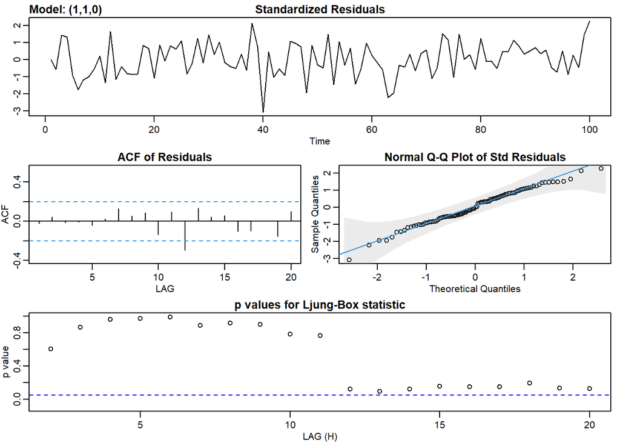

```
## $fit
##
## Call:
## stats::arima(x = xdata, order = c(p, d, q), seasonal = list(order = c(P, D,
##     Q), period = S), xreg = constant, transform.pars = trans, fixed = fixed,
##     optim.control = list(trace = trc, REPORT = 1, reltol = tol))
##
## Coefficients:
##          ar1  constant
##       0.8726   -0.0147
## s.e.  0.0496    0.7017
##
## sigma^2 estimated as 0.8921:  log likelihood = -135.54,  aic = 277.08
##
## $degrees_of_freedom
## [1] 97
##
## $ttable
##          Estimate     SE t.value p.value
## ar1        0.8726 0.0496 17.5823  0.0000
## constant  -0.0147 0.7017 -0.0209  0.9833
##
## $AIC
## [1] 2.798836
##
## $AICc
## [1] 2.800099
##
## $BIC
## [1] 2.877476
```

```r
# Fit model - check t-table and diagnostics
astsa::sarima(x, p = 1, d = 1, q = 0)
```

```r
# Forecast the data 20 time periods ahead
astsa::sarima.for(x, n.ahead = 20, p = 1, d = 1, q = 0)
```

[output not shown]

```
## $pred
## Time Series:
## Start = 101
## End = 120
## Frequency = 1
##  [1] -15.0218971 -12.3590917 -10.0373072  -8.0131092  -6.2485953  -4.7106905
##  [7]  -3.3705325  -2.2029351  -1.1859200  -0.3003082   0.4706368   1.1415196
## [13]   1.7250846   2.2324533   2.6733304   3.0561846   3.3884062   3.6764440
## [19]   3.9259256   4.1417616
##
## $se
## Time Series:
## Start = 101
## End = 120
## Frequency = 1
##  [1]  0.9445349  2.0051651  3.1954564  4.4629953  5.7739609  7.1055712
##  [7]  8.4420413  9.7722824 11.0884824 12.3851782 13.6586198 14.9063226
## [13] 16.1267428 17.3190377 18.4828878 19.6183612 20.7258118 21.8058004
## [19] 22.8590350 23.8863245
```

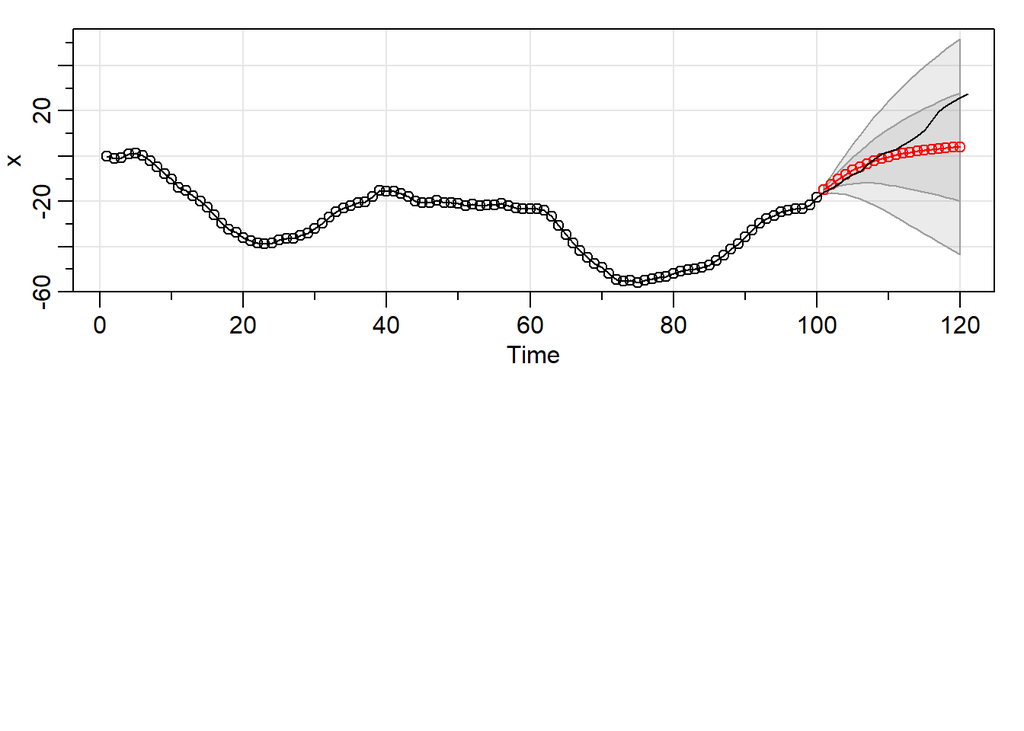

```r
lines(y)
```

**Forecasting global temperatures** Now you can try forecasting real data.

Here, you will forecast the annual global temperature deviations `globtemp` to 2050. Recall that in previous exercises, you fit an ARIMA(0,1,2) model to the data. You will refit the model to confirm it, and then forecast the series 35 years into the future.

The **astsa** package is preloaded and the data are plotted.

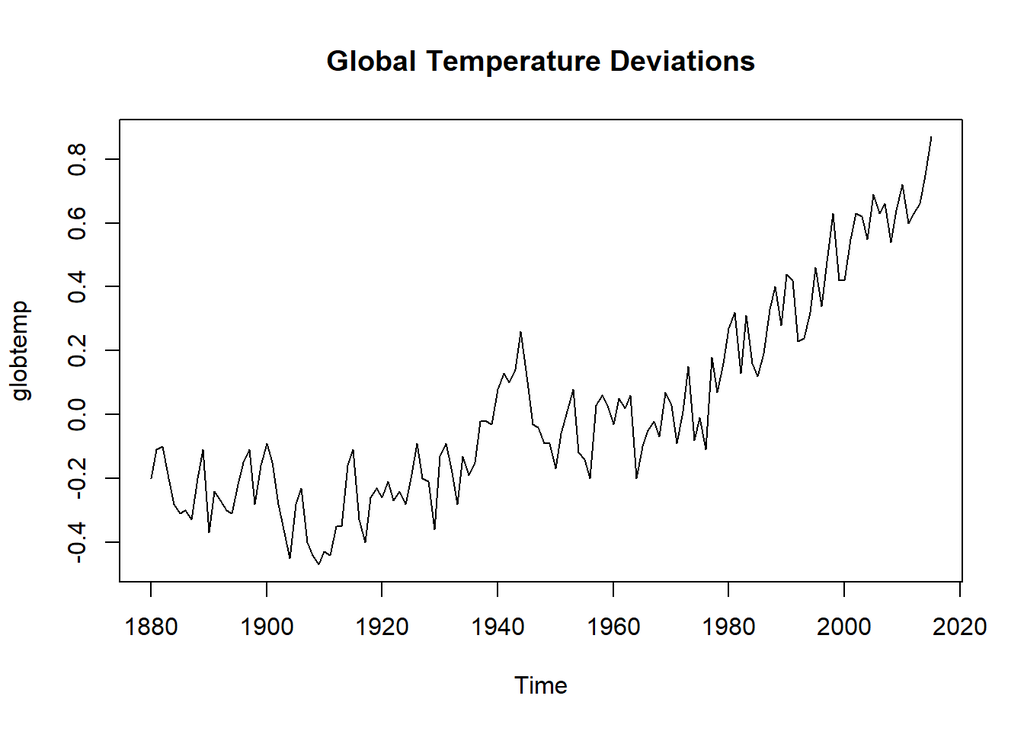

```r
plot(astsa::globtemp, ylab = "globtemp", main = "Global Temperature Deviations")
```

```r
# Fit an ARIMA(0,1,2) to globtemp and check the fit
sarima(globtemp, p = 0, d = 1, q = 2)
```

```
## $fit
##
## Call:
## stats::arima(x = xdata, order = c(p, d, q), seasonal = list(order = c(P, D,
##     Q), period = S), xreg = constant, transform.pars = trans, fixed = fixed,
##     optim.control = list(trace = trc, REPORT = 1, reltol = tol))
##
## Coefficients:
##           ma1      ma2  constant
##       -0.3984  -0.2173    0.0072
## s.e.   0.0808   0.0768    0.0033
##
## sigma^2 estimated as 0.00982:  log likelihood = 120.32,  aic = -232.64
##
## $degrees_of_freedom
## [1] 132
##
## $ttable
##          Estimate     SE t.value p.value
## ma1       -0.3984 0.0808 -4.9313  0.0000
## ma2       -0.2173 0.0768 -2.8303  0.0054
## constant   0.0072 0.0033  2.1463  0.0337
##
## $AIC
## [1] -1.723268
##
## $AICc
## [1] -1.721911
##
## $BIC
## [1] -1.637185
```

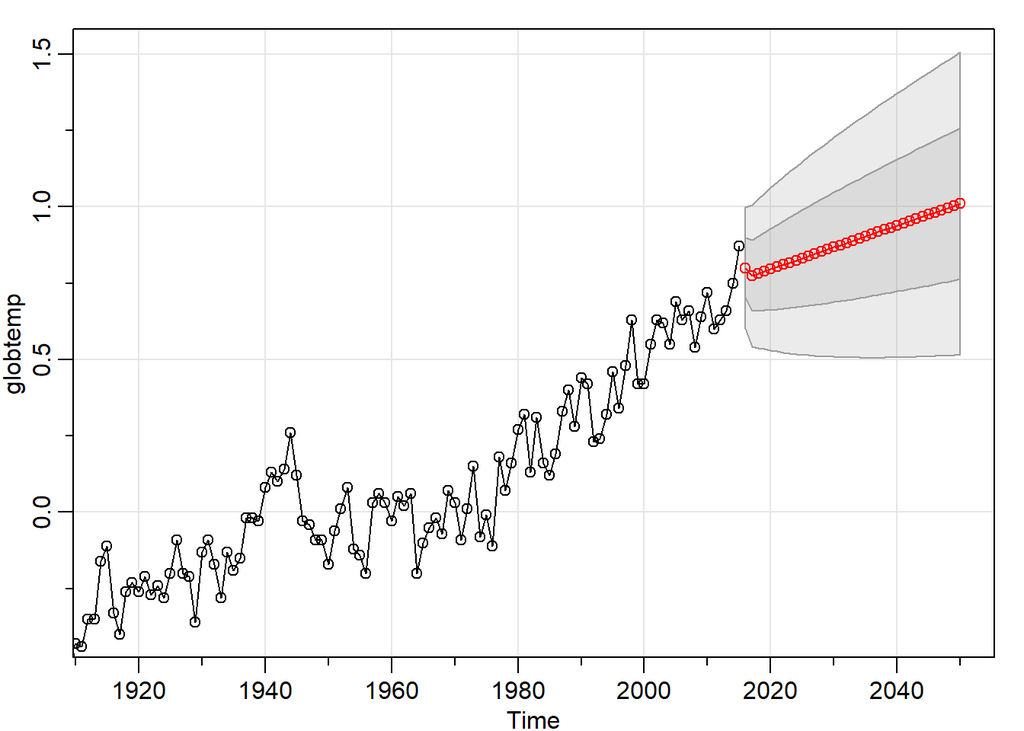

```
## $pred
## Time Series:
## Start = 2016
## End = 2050
## Frequency = 1
##  [1] 0.7995567 0.7745381 0.7816919 0.7888457 0.7959996 0.8031534 0.8103072
##  [8] 0.8174611 0.8246149 0.8317688 0.8389226 0.8460764 0.8532303 0.8603841
## [15] 0.8675379 0.8746918 0.8818456 0.8889995 0.8961533 0.9033071 0.9104610
## [22] 0.9176148 0.9247687 0.9319225 0.9390763 0.9462302 0.9533840 0.9605378
## [29] 0.9676917 0.9748455 0.9819994 0.9891532 0.9963070 1.0034609 1.0106147
##
## $se
## Time Series:
## Start = 2016
## End = 2050
## Frequency = 1
##  [1] 0.09909556 0.11564576 0.12175580 0.12757353 0.13313729 0.13847769
##  [7] 0.14361964 0.14858376 0.15338730 0.15804492 0.16256915 0.16697084
## [13] 0.17125943 0.17544322 0.17952954 0.18352490 0.18743511 0.19126540
## [19] 0.19502047 0.19870459 0.20232164 0.20587515 0.20936836 0.21280424
## [25] 0.21618551 0.21951471 0.22279416 0.22602604 0.22921235 0.23235497
## [31] 0.23545565 0.23851603 0.24153763 0.24452190 0.24747019
```

```r
# Forecast data 35 years into the future
sarima.for(globtemp, n.ahead = 35, p = 0, d = 1, q = 2)
```

In the next chapter, you will learn how to analyze seasonal time series data.

**Pure seasonal models**

- often collect data with a known seasonal component
- air passengers (1 cycle every S = 12 months)
- Johnson & Johnson earnings (1 cycle every S = 4 quarters)

Consider pure seasonal models such as an SAR$(P = 1)_{s=12}$

$X_t = \Phi X_{t-12} + W_t$

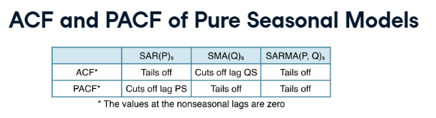

- all lags are at the seasonal level

**Fit a pure seasonal model** As with other models, you can fit seasonal models in R using the `sarima()` command in the **astsa** package.

To get a feeling of how pure seasonal models work, it is best to consider simulated data. We generated 250 observations from a pure seasonal model given by

$X_t = .9X_{t−12} + Wt + .5W_{t−12}$,

which we would denote as a SARMA$(P = 1, Q = 1)_S = 12$. Three years of data and the model ACF and PACF are plotted for you.

You will compare the sample ACF and PACF values from the generated data to the true values.

The `astsa` package is preloaded for you and the generated data are in `x`.

[figure not shown]

```
# Plot sample P/ACF to lag 60 and compare to the true values
acf2(x, max.lag = 60)
```

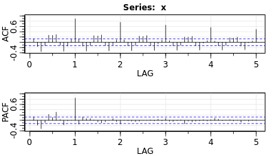

```
# Fit the seasonal model to x
sarima(x, p = 0, d = 0, q = 0, P = 1, D = 0, Q = 1, S = 12)
```

```
Call:
stats::arima(x = xdata, order = c(p, d, q), seasonal = list(order = c(P, D,
    Q), period = S), xreg = xmean, include.mean = FALSE, transform.pars = trans,
    fixed = fixed, optim.control = list(trace = trc, REPORT = 1, reltol = tol))

Coefficients:
        sar1    sma1    xmean
      0.9311  0.4824  -0.5766
s.e.  0.0204  0.0633   0.8797

sigma^2 estimated as 0.9767:  log likelihood = -372.74,  aic = 753.48

$degrees_of_freedom
[1] 249

$ttable
      Estimate     SE t.value p.value
sar1    0.9311 0.0204 45.6189  0.0000
sma1    0.4824 0.0633  7.6158  0.0000
xmean  -0.5766 0.8797 -0.6554  0.5128

$AIC
[1] 2.989992

$AICc
[1] 2.990377

$BIC
[1] 3.046015
```

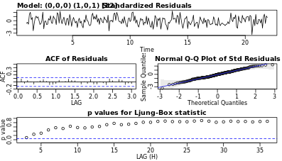

Fitting a seasonal model using `sarima()` requires a few additional arguments, but follows the same basic process as nonseasonal models.

**Mixed seasonal models**

- mixed models: SARIMA$(p, d, q)$ x $(P, D, Q)_s$ model
- consider a SARIMA$(0, 0, 1)$ x $(1, 0, 0)_{12}$ model
  - $X_t = \Phi X_{t-12} + W_t + \theta W_{t-1}$
  - SAR(1): value this month related to last year’s value $X_{t-12}$
  - MA(1): this month’s value related to last month’s shock $W_{t-1}$

**Fit a mixed seasonal model**

Pure seasonal dependence such as that explored earlier in this chapter is relatively rare. Most seasonal time series have *mixed* dependence, meaning only some of the variation is explained by seasonal trends.

Recall that the full seasonal model is denoted by SARIMA$(p,d,q)$x$(P,D,Q)_S$ where capital letters denote the seasonal orders.

As before, this exercise asks you to compare the sample P/ACF pair to the true values for some simulated seasonal data and fit a model to the data using `sarima()`. This time, the simulated data come from a mixed seasonal model, SARIMA$(0,0,1)$x$(0,0,1)_{12}$. The plots show three years of data, as well as the model ACF and PACF. Notice that, as opposed to the pure seasonal model, there are correlations at the nonseasonal lags as well as the seasonal lags.

As always, the [astsa](https://www.rdocumentation.org/packages/astsa/versions/1.6/) package is preloaded. The generated data are in `x`.

[figure not shown]

```
# Plot sample P/ACF pair to lag 60 and compare to actual
acf2(x,  max.lag = 60)
```

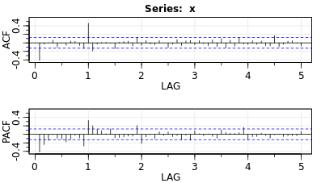

```
# Fit the seasonal model to x
sarima(x, p = 0, d = 0, q = 1, P = 0, D = 0, Q = 1, S = 12)
```

```
Call:
stats::arima(x = xdata, order = c(p, d, q), seasonal = list(order = c(P, D,
    Q), period = S), xreg = xmean, include.mean = FALSE, transform.pars = trans,
    fixed = fixed, optim.control = list(trace = trc, REPORT = 1, reltol = tol))

Coefficients:
          ma1    sma1   xmean
      -0.6142  0.7888  0.0784
s.e.   0.0565  0.0475  0.0430

sigma^2 estimated as 1.005:  log likelihood = -364.26,  aic = 736.52

$degrees_of_freedom
[1] 249

$ttable
      Estimate     SE  t.value p.value
ma1    -0.6142 0.0565 -10.8809  0.0000
sma1    0.7888 0.0475  16.6094  0.0000
xmean   0.0784 0.0430   1.8253  0.0692

$AIC
[1] 2.922696

$AICc
[1] 2.92308

$BIC
[1] 2.978718
```

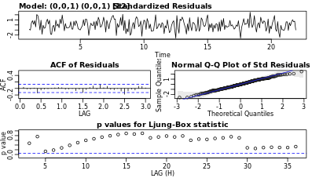

Time series data collected on a seasonal basis typically have mixed dependence. For example, what happens in June is often related to what happened in May as well as what happened in June of last year.

**Data analysis - unemployment I**

In the video, we fit a seasonal ARIMA model to the log of the monthly `AirPassengers` data set. You will now start to fit a seasonal ARIMA model to the monthly US unemployment data, `unemp`, from the `astsa` package.

The first thing to do is to plot the data, notice the trend and the seasonal persistence. Then look at the detrended data and remove the seasonal persistence. After that, the fully differenced data should look stationary.

The **astsa** package is preloaded in your workspace.

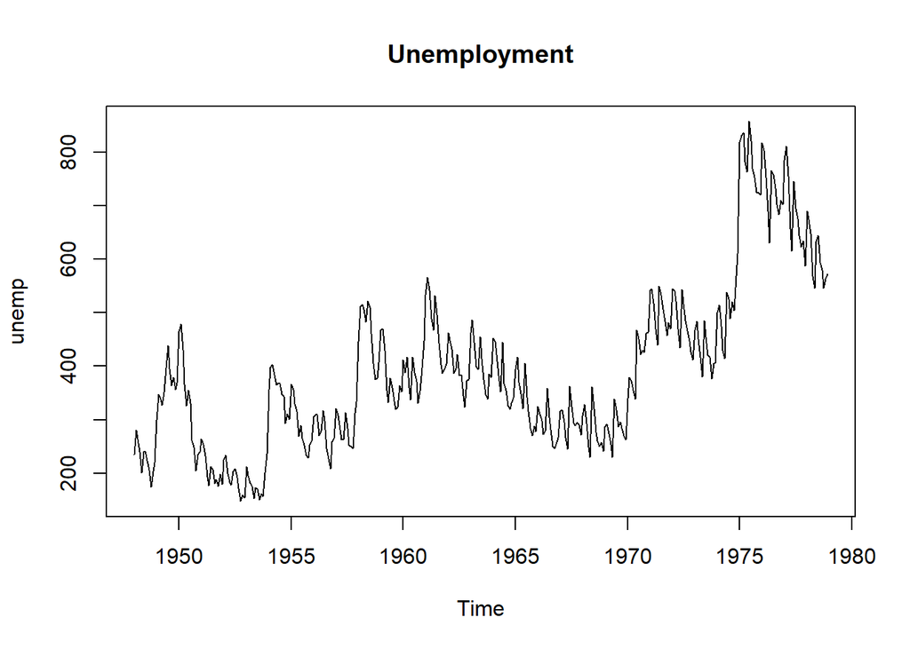

```r
# Plot unemp
plot(unemp, main = "Unemployment")
```

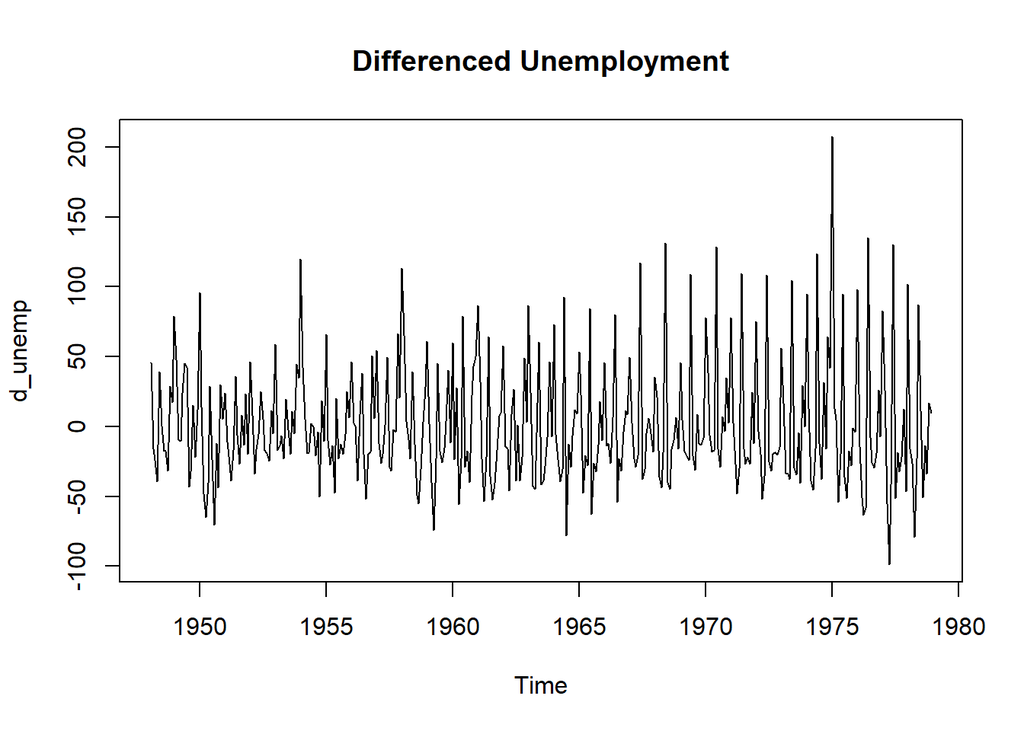

```r
# Difference your data and plot
d_unemp <- diff(unemp)
plot(d_unemp, main = "Differenced Unemployment")
```

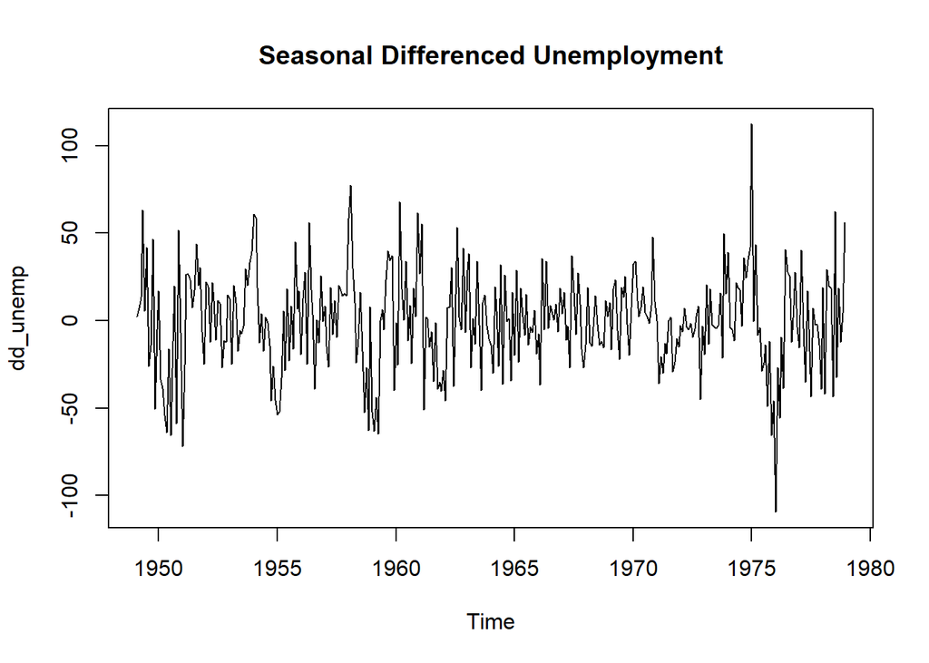

```r
# Plot seasonal differenced diff_unemp
dd_unemp <- diff(d_unemp, lag = 12)
plot(dd_unemp, main = "Seasonal Differenced Unemployment")
```

Now that you have removed the trend and seasonal variation in unemployment, the data appear to be stationary.

**Data analysis - unemployment II**

Now, you will continue fitting an SARIMA model to the monthly US unemployment `unemp` time series by looking at the sample ACF and PACF of the fully differenced series.

*Note that the lag axis in the sample P/ACF plot is in terms of years*. Thus, lags 1, 2, 3, … represent 1 year (12 months), 2 years (24 months), 3 years (36 months), …

Once again, the [astsa](https://www.rdocumentation.org/packages/astsa/versions/1.6/) package is preloaded in your workspace.

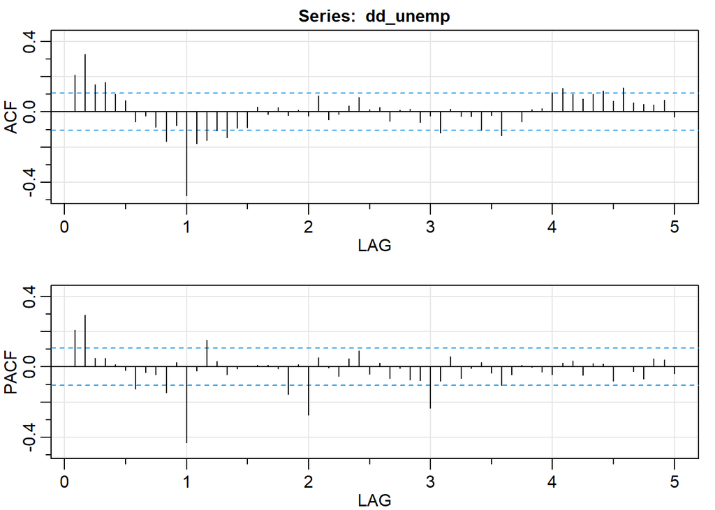

```
##      [,1] [,2] [,3] [,4] [,5]  [,6]  [,7]  [,8]  [,9] [,10] [,11] [,12] [,13]
## ACF  0.21 0.33 0.15 0.17 0.10  0.06 -0.06 -0.02 -0.09 -0.17 -0.08 -0.48 -0.18
## PACF 0.21 0.29 0.05 0.05 0.01 -0.02 -0.12 -0.03 -0.05 -0.15  0.02 -0.43 -0.02
##      [,14] [,15] [,16] [,17] [,18] [,19] [,20] [,21] [,22] [,23] [,24] [,25]
## ACF  -0.16 -0.11 -0.15 -0.09 -0.09  0.03 -0.01  0.02 -0.02  0.01 -0.02  0.09
## PACF  0.15  0.03 -0.04 -0.01  0.00  0.01  0.01 -0.01 -0.16  0.01 -0.27  0.05
##      [,26] [,27] [,28] [,29] [,30] [,31] [,32] [,33] [,34] [,35] [,36] [,37]
## ACF  -0.05 -0.01  0.03  0.08  0.01  0.03 -0.05  0.01  0.02 -0.06 -0.02 -0.12
## PACF -0.01 -0.05  0.05  0.09 -0.04  0.02 -0.07 -0.01 -0.08 -0.08 -0.23 -0.08
##      [,38] [,39] [,40] [,41] [,42] [,43] [,44] [,45] [,46] [,47] [,48] [,49]
## ACF   0.01 -0.03 -0.03 -0.10 -0.02 -0.13  0.00 -0.06  0.01  0.02  0.11  0.13
## PACF  0.06 -0.07 -0.01  0.03 -0.03 -0.11 -0.04  0.01  0.00 -0.03 -0.04  0.02
##      [,50] [,51] [,52] [,53] [,54] [,55] [,56] [,57] [,58] [,59] [,60]
## ACF   0.10  0.07  0.10  0.12  0.06  0.14  0.05  0.04  0.04  0.07 -0.03
## PACF  0.03 -0.05  0.02  0.02 -0.08  0.00 -0.03 -0.07  0.05  0.04 -0.04
```

```r
# Plot P/ACF pair of the fully differenced data to lag 60
dd_unemp <- diff(diff(unemp), lag = 12)
acf2(dd_unemp, max.lag = 60)
```

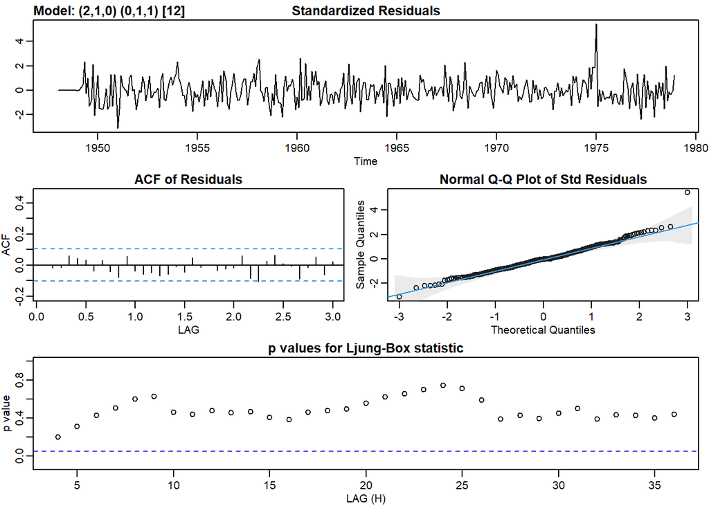

```
## $fit
##
## Call:
## stats::arima(x = xdata, order = c(p, d, q), seasonal = list(order = c(P, D,
##     Q), period = S), include.mean = !no.constant, transform.pars = trans, fixed = fixed,
##     optim.control = list(trace = trc, REPORT = 1, reltol = tol))
##
## Coefficients:
##          ar1     ar2     sma1
##       0.1351  0.2464  -0.6953
## s.e.  0.0513  0.0515   0.0381
##
## sigma^2 estimated as 449.6:  log likelihood = -1609.91,  aic = 3227.81
##
## $degrees_of_freedom
## [1] 356
##
## $ttable
##      Estimate     SE  t.value p.value
## ar1    0.1351 0.0513   2.6326  0.0088
## ar2    0.2464 0.0515   4.7795  0.0000
## sma1  -0.6953 0.0381 -18.2362  0.0000
##
## $AIC
## [1] 8.723811
##
## $AICc
## [1] 8.723988
##
## $BIC
## [1] 8.765793
```

```r
# Fit an appropriate model
sarima(unemp, p = 2, d = 1, q = 0, P = 0, D = 1, Q = 1, S = 12)
```

As always, keep a close eye on the output from your `sarima()` command to get a feel for the fit of your model.

**Data analysis - commodity prices**

Making money in commodities is not easy. Most commodities traders lose money rather than make it. The package `astsa` includes the data set `chicken`, which is the monthly whole bird spot price, Georgia docks, US cents per pound, from August, 2001 to July, 2016.

The [astsa](https://www.rdocumentation.org/packages/astsa/versions/1.6/) package is preloaded in your R console and the data are plotted for you, note the trend and seasonal components.

First, you will use your skills to carefully fit an SARIMA model to the commodity. Later, you will use the fitted model to try and forecast the whole bird spot price.

After removing the trend, the sample ACF and PACF suggest an AR(2) model because the PACF cuts off after lag 2 and the ACF tails off. However, the ACF has a small seasonal component remaining. This can be taken care of by fitting an addition SAR(1) component.

By the way, if you are interested in analyzing other commodities from various regions, you can find many different time series at [index mundi](http://www.indexmundi.com/commodities/).

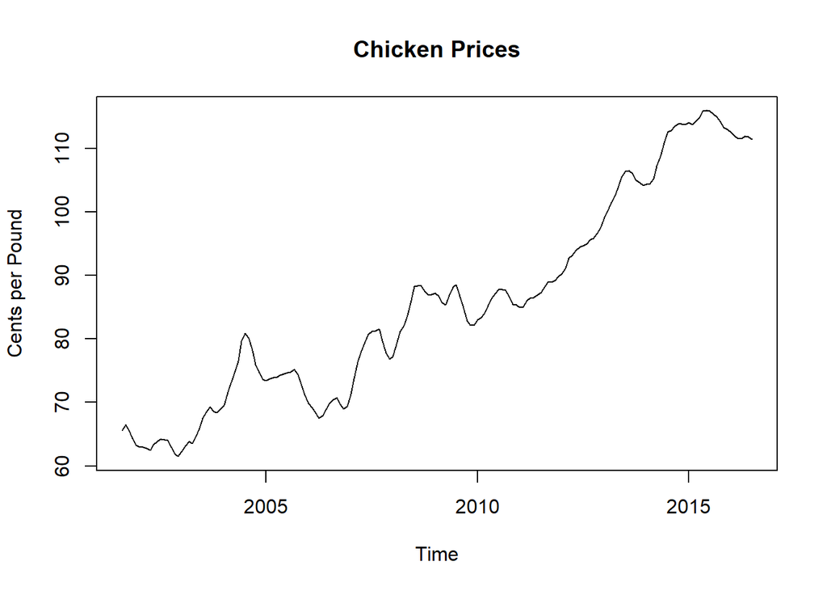

```r
plot(chicken, ylab = "Cents per Pound", main = "Chicken Prices")
```

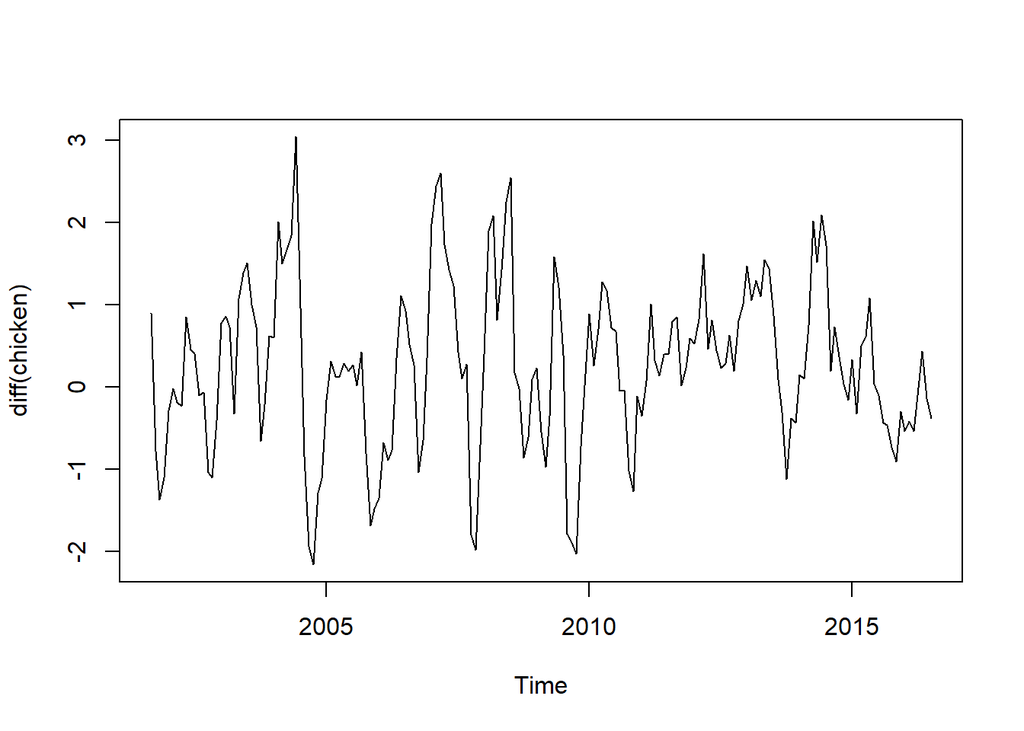

```r
# Plot differenced chicken
plot(diff(chicken))
```

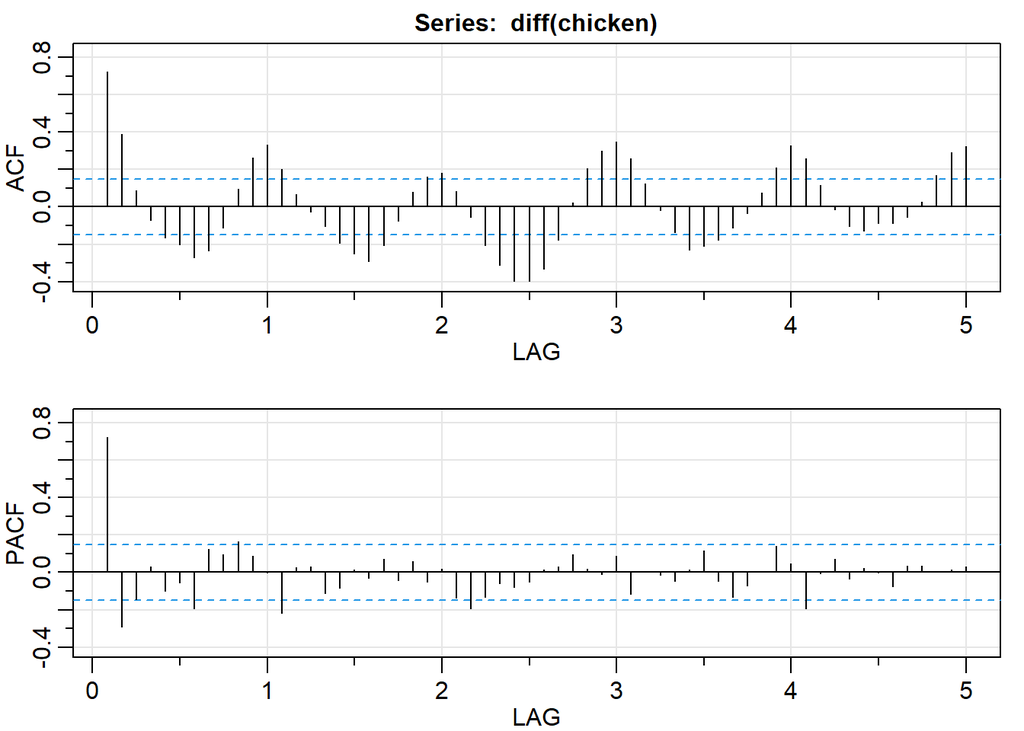

```
##      [,1]  [,2]  [,3]  [,4]  [,5]  [,6]  [,7]  [,8]  [,9] [,10] [,11] [,12]
## ACF  0.72  0.39  0.09 -0.07 -0.16 -0.20 -0.27 -0.23 -0.11  0.09  0.26  0.33
## PACF 0.72 -0.29 -0.14  0.03 -0.10 -0.06 -0.19  0.12  0.10  0.16  0.09  0.00
##      [,13] [,14] [,15] [,16] [,17] [,18] [,19] [,20] [,21] [,22] [,23] [,24]
## ACF   0.20  0.07 -0.03 -0.10 -0.19 -0.25 -0.29 -0.20 -0.08  0.08  0.16  0.18
## PACF -0.22  0.03  0.03 -0.11 -0.09  0.01 -0.03  0.07 -0.04  0.06 -0.05  0.02
##      [,25] [,26] [,27] [,28] [,29] [,30] [,31] [,32] [,33] [,34] [,35] [,36]
## ACF   0.08 -0.06 -0.21 -0.31 -0.40 -0.40 -0.33 -0.18  0.02  0.20  0.30  0.35
## PACF -0.14 -0.19 -0.13 -0.06 -0.08 -0.05  0.01  0.03  0.10  0.02 -0.01  0.09
##      [,37] [,38] [,39] [,40] [,41] [,42] [,43] [,44] [,45] [,46] [,47] [,48]
## ACF   0.26  0.13 -0.02 -0.14 -0.23 -0.21 -0.18 -0.11 -0.03  0.08  0.21  0.33
## PACF -0.12  0.01 -0.01 -0.05  0.02  0.12 -0.05 -0.13 -0.07  0.01  0.14  0.05
##      [,49] [,50] [,51] [,52] [,53] [,54] [,55] [,56] [,57] [,58] [,59] [,60]
## ACF   0.26  0.12 -0.01 -0.11 -0.13 -0.09 -0.09 -0.06  0.03  0.17  0.29  0.32
## PACF -0.20 -0.01  0.07 -0.04  0.02  0.00 -0.08  0.03  0.04  0.00  0.01  0.03
```

```r
# Plot P/ACF pair of differenced data to lag 60
acf2(diff(chicken), max.lag = 60)
```

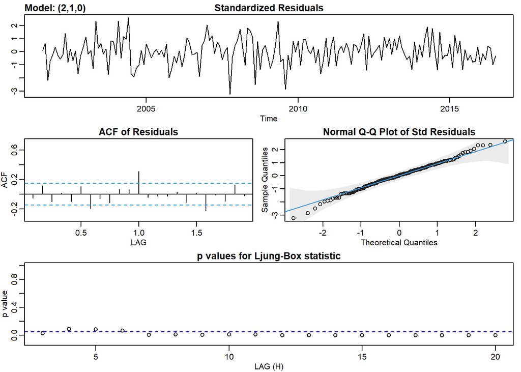

```
## $fit
##
## Call:
## stats::arima(x = xdata, order = c(p, d, q), seasonal = list(order = c(P, D,
##     Q), period = S), xreg = constant, transform.pars = trans, fixed = fixed,
##     optim.control = list(trace = trc, REPORT = 1, reltol = tol))
##
## Coefficients:
##          ar1      ar2  constant
##       0.9494  -0.3069    0.2632
## s.e.  0.0717   0.0718    0.1362
##
## sigma^2 estimated as 0.4286:  log likelihood = -178.64,  aic = 365.28
##
## $degrees_of_freedom
## [1] 176
##
## $ttable
##          Estimate     SE t.value p.value
## ar1        0.9494 0.0717 13.2339  0.0000
## ar2       -0.3069 0.0718 -4.2723  0.0000
## constant   0.2632 0.1362  1.9328  0.0549
##
## $AIC
## [1] 2.040695
##
## $AICc
## [1] 2.041461
##
## $BIC
## [1] 2.111922
```

```r
# Fit ARIMA(2,1,0) to chicken - not so good
sarima(chicken, p = 2, d = 1, q = 0)
```

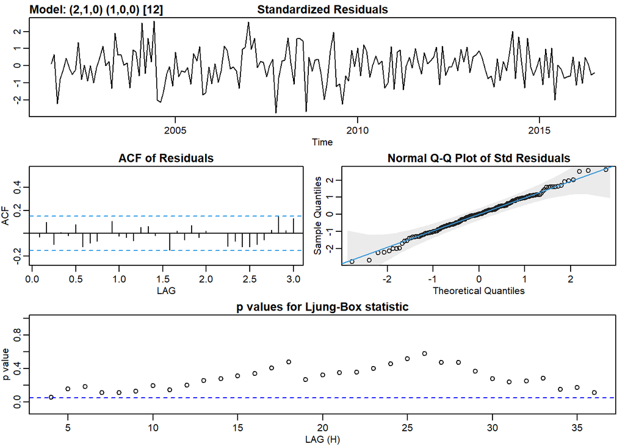

```
## $fit
##
## Call:
## stats::arima(x = xdata, order = c(p, d, q), seasonal = list(order = c(P, D,
##     Q), period = S), xreg = constant, transform.pars = trans, fixed = fixed,
##     optim.control = list(trace = trc, REPORT = 1, reltol = tol))
##
## Coefficients:
##          ar1      ar2    sar1  constant
##       0.9154  -0.2494  0.3237    0.2353
## s.e.  0.0733   0.0739  0.0715    0.1973
##
## sigma^2 estimated as 0.3828:  log likelihood = -169.16,  aic = 348.33
##
## $degrees_of_freedom
## [1] 175
##
## $ttable
##          Estimate     SE t.value p.value
## ar1        0.9154 0.0733 12.4955  0.0000
## ar2       -0.2494 0.0739 -3.3728  0.0009
## sar1       0.3237 0.0715  4.5238  0.0000
## constant   0.2353 0.1973  1.1923  0.2347
##
## $AIC
## [1] 1.945971
##
## $AICc
## [1] 1.947256
##
## $BIC
## [1] 2.035005
```

```r
# Fit SARIMA(2,1,0,1,0,0,12) to chicken - that works
sarima(chicken, p = 2, d = 1, q = 0, P = 1, D = 0, Q = 0, S = 12)
```

You have successfully fit an ARIMA model to a commodity. If you are interested in analyzing other commodities from various regions, you can find many different time series at [index mundi](http://www.indexmundi.com/commodities/)

**Data analysis - birth rate**

Now you will use your new skills to carefully fit an SARIMA model to the `birth` time series from `astsa`. The data are monthly live births (adjusted) in thousands for the United States, 1948-1979, and includes the baby boom after WWII.

The `birth` data are plotted in your R console. Note the long-term trend (random walk) and the seasonal component of the data.

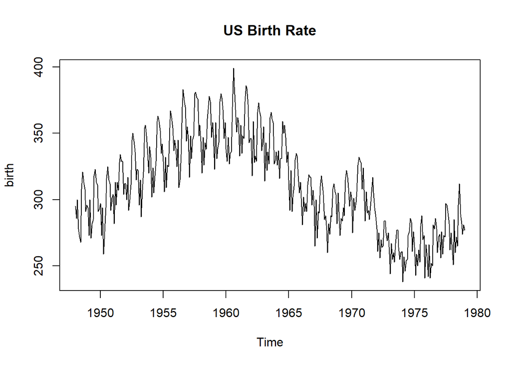

```r
plot(birth, main="US Birth Rate")
```

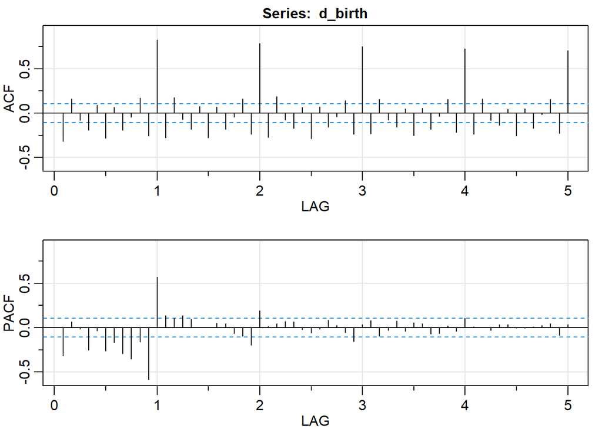

```
##       [,1] [,2]  [,3]  [,4]  [,5]  [,6]  [,7]  [,8]  [,9] [,10] [,11] [,12]
## ACF  -0.32 0.16 -0.08 -0.19  0.09 -0.28  0.06 -0.19 -0.05  0.17 -0.26  0.82
## PACF -0.32 0.06 -0.01 -0.25 -0.03 -0.26 -0.17 -0.29 -0.35 -0.16 -0.59  0.57
##      [,13] [,14] [,15] [,16] [,17] [,18] [,19] [,20] [,21] [,22] [,23] [,24]
## ACF  -0.28  0.17 -0.07 -0.18  0.08 -0.28  0.07 -0.18 -0.05  0.16 -0.24  0.78
## PACF  0.13  0.11  0.13  0.09  0.00  0.00  0.05  0.04 -0.07 -0.10 -0.20  0.19
##      [,25] [,26] [,27] [,28] [,29] [,30] [,31] [,32] [,33] [,34] [,35] [,36]
## ACF  -0.27  0.19 -0.08 -0.17  0.07 -0.29  0.07 -0.15 -0.04  0.14 -0.24  0.75
## PACF  0.01  0.05  0.07  0.07 -0.02 -0.06 -0.02  0.09  0.03 -0.06 -0.16  0.03
##      [,37] [,38] [,39] [,40] [,41] [,42] [,43] [,44] [,45] [,46] [,47] [,48]
## ACF  -0.23  0.16 -0.08 -0.15  0.05 -0.25  0.06 -0.18 -0.03  0.15 -0.22  0.72
## PACF  0.08 -0.10 -0.03  0.07 -0.04  0.06  0.04 -0.07 -0.06  0.02 -0.04  0.10
##      [,49] [,50] [,51] [,52] [,53] [,54] [,55] [,56] [,57] [,58] [,59] [,60]
## ACF  -0.24  0.16 -0.08 -0.13  0.05 -0.26  0.05 -0.17 -0.02  0.15 -0.23  0.70
## PACF  0.01  0.00 -0.03  0.04  0.03  0.00 -0.01  0.01  0.03  0.04 -0.09  0.04
```

```r
# Plot P/ACF to lag 60 of differenced data
d_birth <- diff(birth)
acf2(d_birth, max.lag = 60)
```

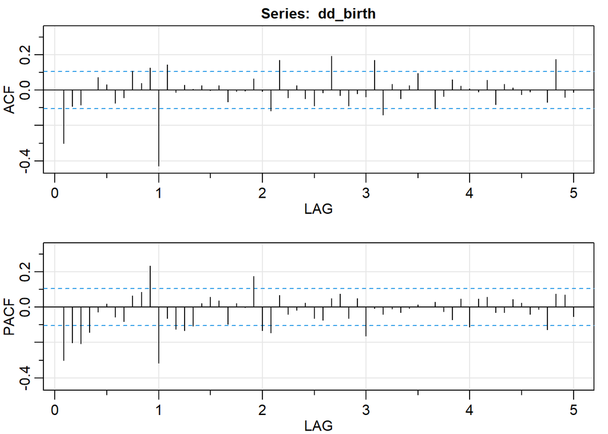

```
##      [,1]  [,2]  [,3]  [,4]  [,5] [,6]  [,7]  [,8] [,9] [,10] [,11] [,12] [,13]
## ACF  -0.3 -0.09 -0.09  0.00  0.07 0.03 -0.07 -0.04 0.11  0.04  0.13 -0.43  0.14
## PACF -0.3 -0.20 -0.21 -0.14 -0.03 0.02 -0.06 -0.08 0.06  0.08  0.23 -0.32 -0.06
##      [,14] [,15] [,16] [,17] [,18] [,19] [,20] [,21] [,22] [,23] [,24] [,25]
## ACF  -0.01  0.03  0.01  0.02  0.00  0.03 -0.07 -0.01     0  0.06 -0.01 -0.12
## PACF -0.13 -0.13 -0.11  0.02  0.06  0.04 -0.10  0.02     0  0.17 -0.13 -0.14
##      [,26] [,27] [,28] [,29] [,30] [,31] [,32] [,33] [,34] [,35] [,36] [,37]
## ACF   0.17 -0.04  0.03 -0.05 -0.09 -0.01  0.19 -0.03 -0.09 -0.02 -0.04  0.17
## PACF  0.07 -0.04 -0.02  0.02 -0.06 -0.07  0.05  0.07 -0.06  0.05 -0.16 -0.01
##      [,38] [,39] [,40] [,41] [,42] [,43] [,44] [,45] [,46] [,47] [,48] [,49]
## ACF  -0.14  0.03 -0.05  0.03  0.10     0 -0.10 -0.03  0.06  0.02  0.01 -0.01
## PACF -0.04 -0.01 -0.03 -0.01  0.01     0  0.03 -0.02 -0.07  0.05 -0.11  0.05
##      [,50] [,51] [,52] [,53] [,54] [,55] [,56] [,57] [,58] [,59] [,60]
## ACF   0.06 -0.08  0.03  0.01 -0.02 -0.01  0.00 -0.07  0.17 -0.04 -0.01
## PACF  0.06 -0.03 -0.03  0.04  0.02 -0.04 -0.01 -0.13  0.07  0.07 -0.05
```

```r
# Plot P/ACF to lag 60 of seasonal differenced data
dd_birth <- diff(d_birth, lag = 12)
acf2(dd_birth, max.lag = 60)
```

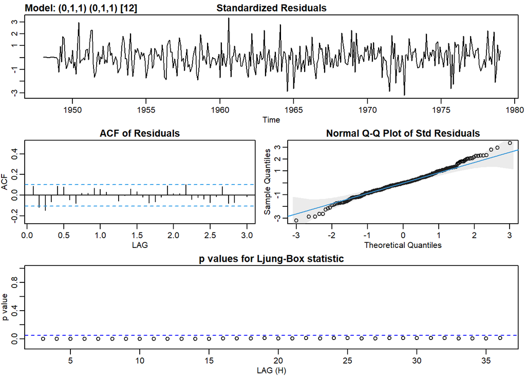

```
## $fit
##
## Call:
## stats::arima(x = xdata, order = c(p, d, q), seasonal = list(order = c(P, D,
##     Q), period = S), include.mean = !no.constant, transform.pars = trans, fixed = fixed,
##     optim.control = list(trace = trc, REPORT = 1, reltol = tol))
##
## Coefficients:
##           ma1     sma1
##       -0.4734  -0.7861
## s.e.   0.0598   0.0451
##
## sigma^2 estimated as 47.4:  log likelihood = -1211.28,  aic = 2428.56
##
## $degrees_of_freedom
## [1] 358
##
## $ttable
##      Estimate     SE  t.value p.value
## ma1   -0.4734 0.0598  -7.9097       0
## sma1  -0.7861 0.0451 -17.4227       0
##
## $AIC
## [1] 6.545975
##
## $AICc
## [1] 6.546062
##
## $BIC
## [1] 6.577399
```

```r
# Fit SARIMA(0,1,1)x(0,1,1)_12. What happens?
sarima(birth, p = 0, d = 1, q = 1, P = 0, D = 1, Q = 1, S = 12)
```

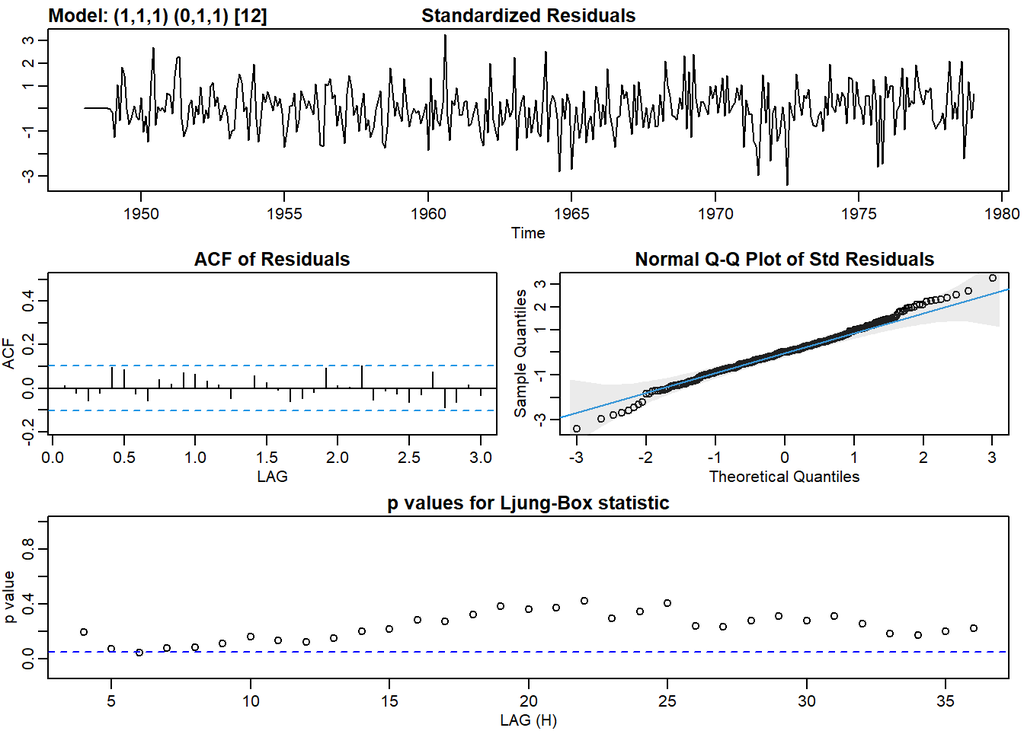

```
## $fit
##
## Call:
## stats::arima(x = xdata, order = c(p, d, q), seasonal = list(order = c(P, D,
##     Q), period = S), include.mean = !no.constant, transform.pars = trans, fixed = fixed,
##     optim.control = list(trace = trc, REPORT = 1, reltol = tol))
##
## Coefficients:
##          ar1      ma1     sma1
##       0.3038  -0.7006  -0.8000
## s.e.  0.0865   0.0604   0.0441
##
## sigma^2 estimated as 45.91:  log likelihood = -1205.93,  aic = 2419.85
##
## $degrees_of_freedom
## [1] 357
##
## $ttable
##      Estimate     SE  t.value p.value
## ar1    0.3038 0.0865   3.5104   5e-04
## ma1   -0.7006 0.0604 -11.5984   0e+00
## sma1  -0.8000 0.0441 -18.1302   0e+00
##
## $AIC
## [1] 6.522519
##
## $AICc
## [1] 6.522695
##
## $BIC
## [1] 6.564418
```

```r
# Fit another model, this time with an AR
sarima(birth, p = 1, d = 1, q = 1, P = 0, D = 1, Q = 1, S = 12)
```

The residual analysis from the first fit indicated that the residuals were not white noise. Hence, it was necessary to include an additional nonseasonal AR term to account for the extra correlation.

**Forecasting seasonal ARIMA**

**Forecasting monthly unemployment**

Previously, you fit an SARIMA$(2,1,0, 0,1,1)_{12}$ model to the monthly US unemployment time series `unemp`. You will now use that model to forecast the data 3 years.

The `unemp` data are preloaded into your R workspace and plotted.

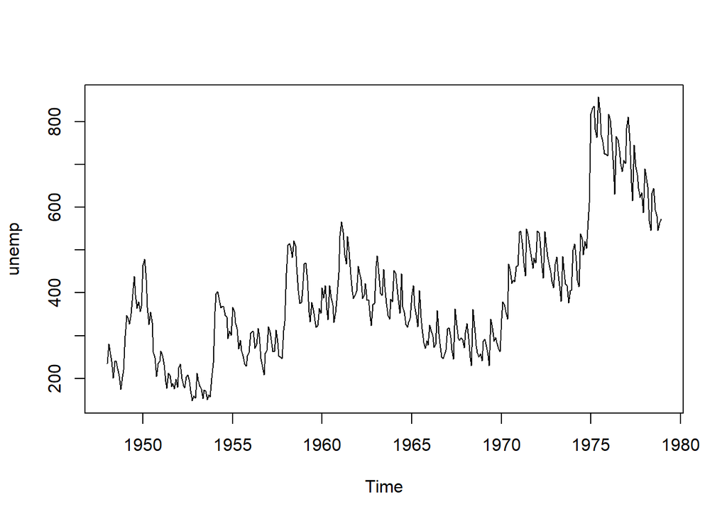

```r
plot(unemp)
```

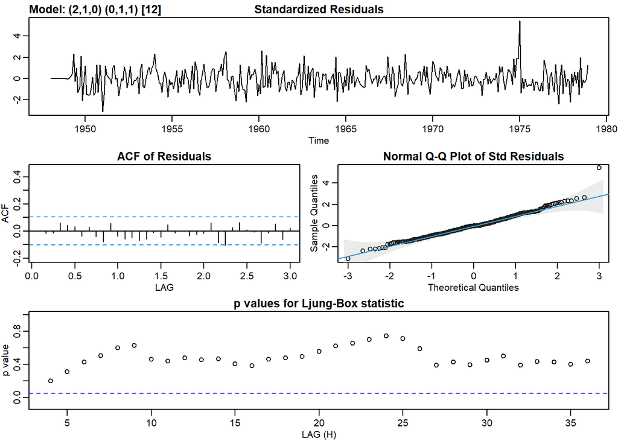

```
## $fit
##
## Call:
## stats::arima(x = xdata, order = c(p, d, q), seasonal = list(order = c(P, D,
##     Q), period = S), include.mean = !no.constant, transform.pars = trans, fixed = fixed,
##     optim.control = list(trace = trc, REPORT = 1, reltol = tol))
##
## Coefficients:
##          ar1     ar2     sma1
##       0.1351  0.2464  -0.6953
## s.e.  0.0513  0.0515   0.0381
##
## sigma^2 estimated as 449.6:  log likelihood = -1609.91,  aic = 3227.81
##
## $degrees_of_freedom
## [1] 356
##
## $ttable
##      Estimate     SE  t.value p.value
## ar1    0.1351 0.0513   2.6326  0.0088
## ar2    0.2464 0.0515   4.7795  0.0000
## sma1  -0.6953 0.0381 -18.2362  0.0000
##
## $AIC
## [1] 8.723811
##
## $AICc
## [1] 8.723988
##
## $BIC
## [1] 8.765793
```

```r
# Fit your previous model to unemp and check the diagnostics
sarima(unemp, p = 2, d = 1, q = 0, P = 0, D = 1, Q = 1, S = 12)
```

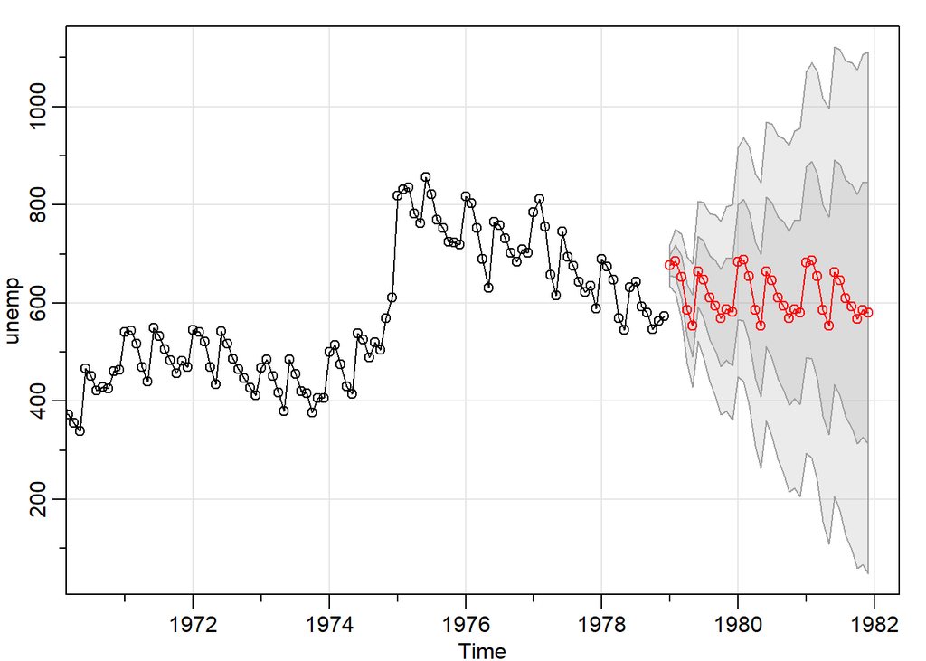

```
## $pred
##           Jan      Feb      Mar      Apr      May      Jun      Jul      Aug
## 1979 676.4664 685.1172 653.2388 585.6939 553.8813 664.4072 647.0657 611.0828
## 1980 683.3045 687.7649 654.8658 586.1507 553.9285 664.1108 646.6220 610.5345
## 1981 682.6406 687.0977 654.1968 585.4806 553.2579 663.4398 645.9508 609.8632
##           Sep      Oct      Nov      Dec
## 1979 594.6414 569.3997 587.5801 581.1833
## 1980 594.0427 568.7684 586.9320 580.5249
## 1981 593.3713 568.0970 586.2606 579.8535
##
## $se
##            Jan       Feb       Mar       Apr       May       Jun       Jul
## 1979  21.20465  32.07710  43.70167  53.66329  62.85364  71.12881  78.73590
## 1980 116.99599 124.17344 131.51281 138.60466 145.49706 152.12863 158.52302
## 1981 194.25167 201.10648 208.17066 215.11503 221.96039 228.64285 235.16874
##            Aug       Sep       Oct       Nov       Dec
## 1979  85.75096  92.28663  98.41329 104.19488 109.67935
## 1980 164.68623 170.63839 176.39520 181.97333 187.38718
## 1981 241.53258 247.74268 253.80549 259.72970 265.52323
```

```r
# Forecast the data 3 years into the future
sarima.for(unemp, n.ahead = 36, p = 2, d = 1, q = 0, P = 0, D = 1, Q = 1, S = 12)
```

As you can see, the forecast is able to replicate much of the seasonal variation in the original unemployment data.

**How hard is it to forecast commodity prices?**

As previously mentioned, making money in commodities is not easy. To see a difficulty in predicting a commodity, you will forecast the price of chicken to five years in the future. When you complete your forecasts, you will note that even just a few years out, the acceptable range of prices is very large. This is because commodities are subject to many sources of variation.

Recall that you previously fit an SARIMA$(2,1,0, 1,0,0)_{12}$ model to the monthly US chicken price series `chicken`. You will use this model to calculate your forecasts.

The [astsa](https://www.rdocumentation.org/packages/astsa/versions/1.6/) package is preloaded for you and the monthly price of chicken data (`chicken`) are plotted.

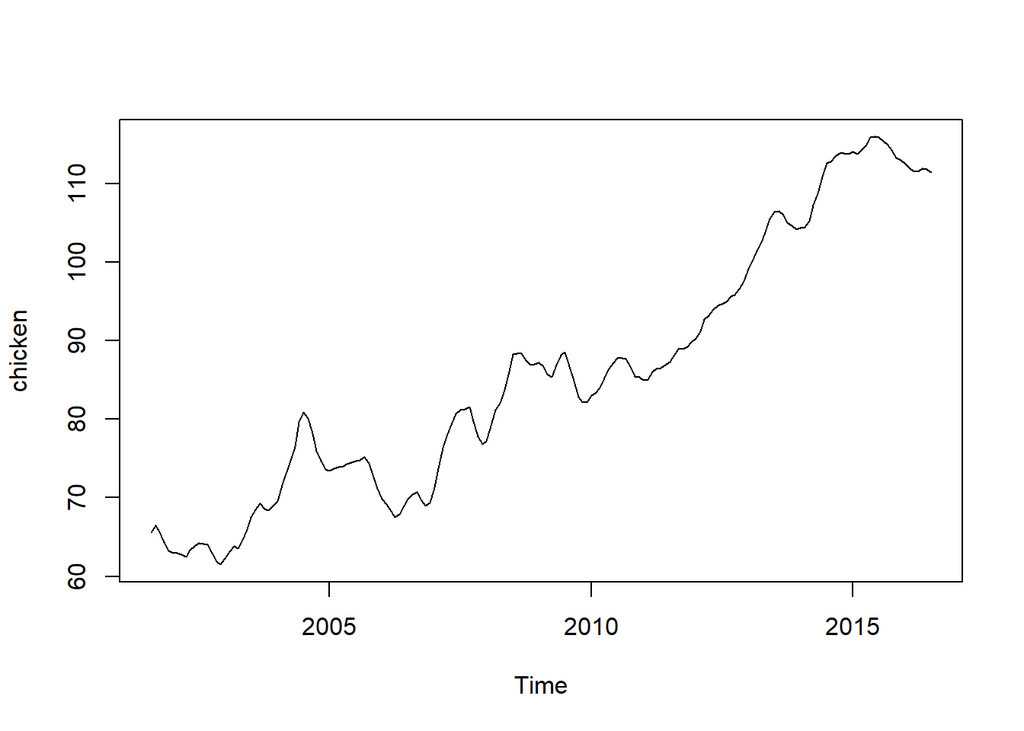

```r
plot(chicken)
```

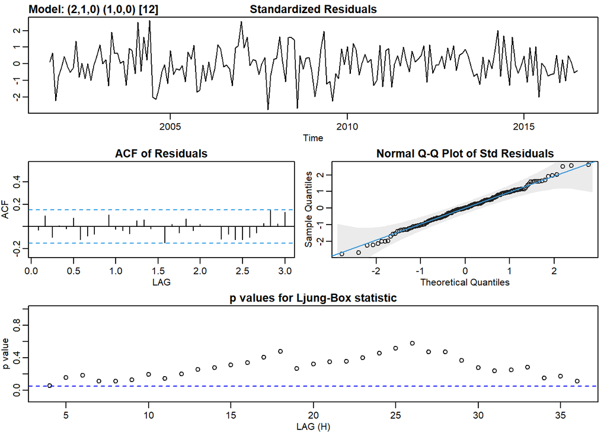

```
## $fit
##
## Call:
## stats::arima(x = xdata, order = c(p, d, q), seasonal = list(order = c(P, D,
##     Q), period = S), xreg = constant, transform.pars = trans, fixed = fixed,
##     optim.control = list(trace = trc, REPORT = 1, reltol = tol))
##
## Coefficients:
##          ar1      ar2    sar1  constant
##       0.9154  -0.2494  0.3237    0.2353
## s.e.  0.0733   0.0739  0.0715    0.1973
##
## sigma^2 estimated as 0.3828:  log likelihood = -169.16,  aic = 348.33
##
## $degrees_of_freedom
## [1] 175
##
## $ttable
##          Estimate     SE t.value p.value
## ar1        0.9154 0.0733 12.4955  0.0000
## ar2       -0.2494 0.0739 -3.3728  0.0009
## sar1       0.3237 0.0715  4.5238  0.0000
## constant   0.2353 0.1973  1.1923  0.2347
##
## $AIC
## [1] 1.945971
##
## $AICc
## [1] 1.947256
##
## $BIC
## [1] 2.035005
```

```r
# Fit the chicken model again and check diagnostics
sarima(chicken, p = 2, d = 1, q = 0, P = 1, D = 0, Q = 0, S = 12)
```

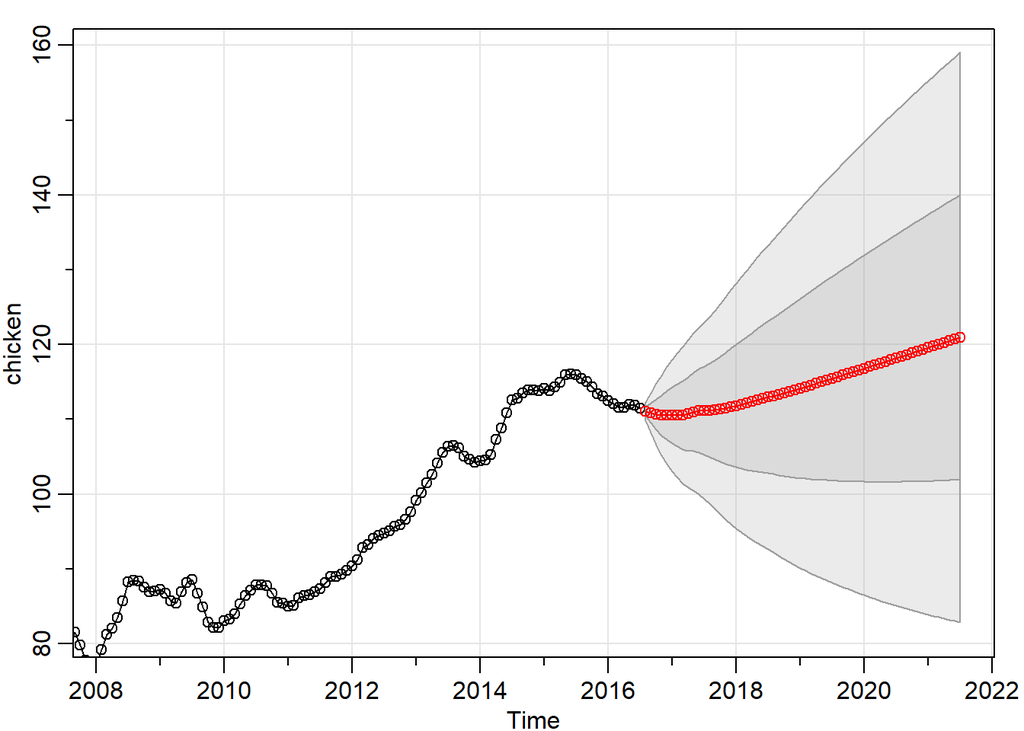

```
## $pred
##           Jan      Feb      Mar      Apr      May      Jun      Jul      Aug
## 2016                                                                111.0907
## 2017 110.5358 110.5612 110.5480 110.7055 111.0047 111.1189 111.1552 111.1948
## 2018 111.8108 111.9782 112.1330 112.3431 112.5991 112.7952 112.9661 113.1380
## 2019 114.1331 114.3464 114.5556 114.7827 115.0247 115.2473 115.4617 115.6765
## 2020 116.7942 117.0224 117.2492 117.4819 117.7193 117.9505 118.1790 118.4077
## 2021 119.5651 119.7980 120.0306 120.2650 120.5010 120.7350 120.9681
##           Sep      Oct      Nov      Dec
## 2016 110.8740 110.6853 110.5045 110.5527
## 2017 111.2838 111.3819 111.4825 111.6572
## 2018 113.3260 113.5168 113.7085 113.9242
## 2019 115.8965 116.1174 116.3386 116.5675
## 2020 118.6380 118.8686 119.0993 119.3326
## 2021
```

[output cut: 16 more lines]

```r
# Forecast the chicken data 5 years into the future
sarima.for(chicken, n.ahead = 60, p = 2, d = 1, q = 0, P = 1, D = 0, Q = 0, S = 12)
```

You have now mastered the process of detrending your time series data, exploring the qualities of the data to determine an appropriate model, fitting and adjusting a model, and even forecasting based on the model!

**Congratulations!**

**What you’ve learned**

- how to identify an ARMA model from data looking at ACF and PACF
- how to use integrated ARMA (ARIMA) models for nonstationary time series
- how to cope with seasonality

**Don’t stop here**

- `astsa` package
- other DataCamp courses in Time Series Analysis